# Coffee Cupper Points Prediction

Mateusz Majak

14.09.2020

# 1 About dataset

I decided to analyse the arabica coffees statistics scraped from the Coffee Quality Institute dataset and published by James LeDoux on https://github.com/jldbc/coffee-quality-database.

Coffee Quality Institute runs a Q Program, which identifies quality coffees across the World. One of the target of program is possibility of comparising coffees from other continents.

Let’s look on the data:

```r
glimpse(coffee_full)
```

```
## Rows: 1,311
## Columns: 44
## $ X                     <int> 1, 2, 3, 4, 5, 6, 7, 8, 9, 10, 11, 12, 13, 14...
## $ Species               <chr> "Arabica", "Arabica", "Arabica", "Arabica", "...
## $ Owner                 <chr> "metad plc", "metad plc", "grounds for health...
## $ Country.of.Origin     <chr> "Ethiopia", "Ethiopia", "Guatemala", "Ethiopi...
## $ Farm.Name             <chr> "metad plc", "metad plc", "san marcos barranc...
## $ Lot.Number            <chr> NA, NA, NA, NA, NA, NA, NA, NA, NA, NA, NA, N...
## $ Mill                  <chr> "metad plc", "metad plc", NA, "wolensu", "met...
## $ ICO.Number            <chr> "2014/2015", "2014/2015", NA, NA, "2014/2015"...
## $ Company               <chr> "metad agricultural developmet plc", "metad a...
## $ Altitude              <chr> "1950-2200", "1950-2200", "1600 - 1800 m", "1...
## $ Region                <chr> "guji-hambela", "guji-hambela", NA, "oromia",...
## $ Producer              <chr> "METAD PLC", "METAD PLC", NA, "Yidnekachew Da...
## $ Number.of.Bags        <int> 300, 300, 5, 320, 300, 100, 100, 300, 300, 50...
```

[output cut: 31 more lines]

Data contain 1311 coffees with 44 attributes. Some of them are IDs, names, and small regions (unique almost), but most are numeric and categorical variables describing specific parameters quality and parameters of production.

# 2 EDA and data manipulation

I create coffee dataset without clumsy data like row numbers, Lot.Number, unique codes and columns with the same information.

```r
coffee <- coffee_full
coffee[,c("X","Species","Certification.Address","Certification.Contact",
          "Lot.Number","Mill","ICO.Number","Expiration","Grading.Date",
          "Company","Farm.Name","Owner","Producer","Owner.1",
          "In.Country.Partner","Region","Altitude","Certification.Body",
          "Harvest.Year")] <- NULL
```

## 2.1 Missing values

Now let’s look on the missing values:

```r
colSums(is.na(coffee)) %>%
  sort()
```

```
##       Number.of.Bags           Bag.Weight                Aroma
##                    0                    0                    0
##               Flavor           Aftertaste              Acidity
##                    0                    0                    0
##                 Body              Balance           Uniformity
##                    0                    0                    0
##            Clean.Cup            Sweetness        Cupper.Points
##                    0                    0                    0
##     Total.Cup.Points             Moisture Category.One.Defects
##                    0                    0                    0
## Category.Two.Defects  unit_of_measurement    Country.of.Origin
##                    0                    0                    1
##              Quakers    Processing.Method              Variety
##                    1                  152                  201
##                Color  altitude_low_meters altitude_high_meters
##                  216                  227                  227
## altitude_mean_meters
##                  227
```

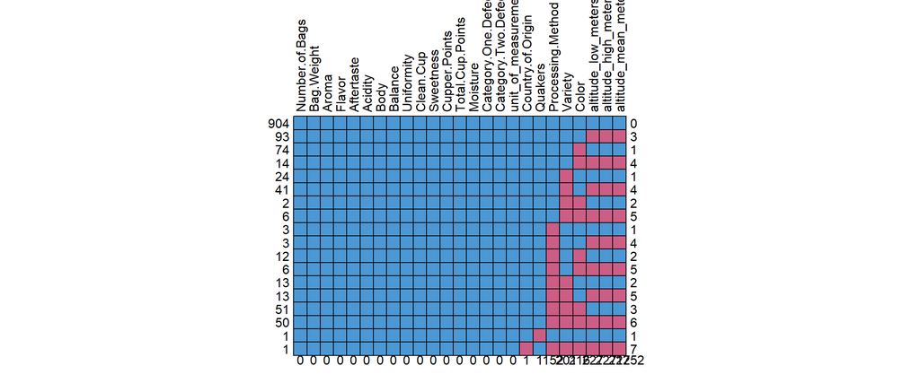

```
##     Number.of.Bags Bag.Weight Aroma Flavor Aftertaste Acidity Body Balance
## 904              1          1     1      1          1       1    1       1
## 93               1          1     1      1          1       1    1       1
## 74               1          1     1      1          1       1    1       1
## 14               1          1     1      1          1       1    1       1
## 24               1          1     1      1          1       1    1       1
## 41               1          1     1      1          1       1    1       1
## 2                1          1     1      1          1       1    1       1
## 6                1          1     1      1          1       1    1       1
## 3                1          1     1      1          1       1    1       1
## 3                1          1     1      1          1       1    1       1
## 12               1          1     1      1          1       1    1       1
## 6                1          1     1      1          1       1    1       1
## 13               1          1     1      1          1       1    1       1
## 13               1          1     1      1          1       1    1       1
```

[output cut: 85 more lines]

```r
coffee %>%
  md.pattern(rotate.names = TRUE)
```

There are 1 NA in Quakers column and 227 NAs in each altitude column.

Dealing with missing value in Quakers column (I replace the missing value with the median):

```r
table(coffee$Quakers, useNA = "ifany")
```

```
##
##    0    1    2    3    4    5    6    7    8    9   11 <NA>
## 1216   39   30    5    5    5    4    3    1    1    1    1
```

```r
coffee$Quakers[is.na(coffee$Quakers)] <- median(coffee$Quakers, na.rm=TRUE)
```

Dealing with missing values in altitudes columns:

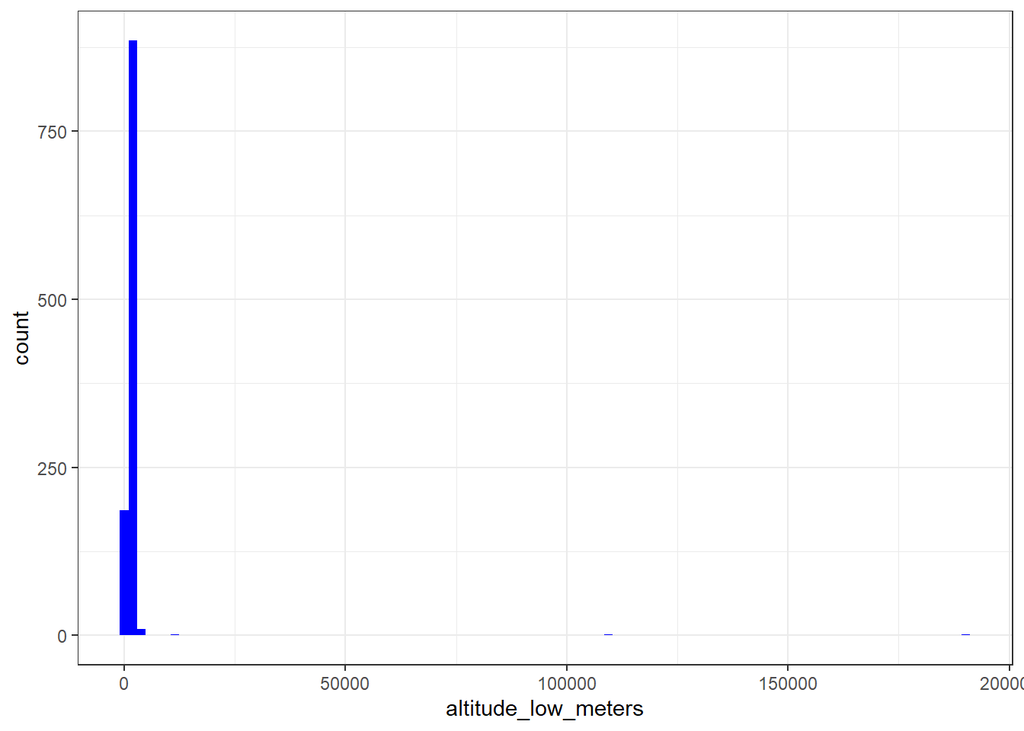

```r
ggplot(coffee,
       aes(x = altitude_low_meters)) +
  geom_histogram(fill = "blue",
                 bins = 100) +
  theme_bw()
```

There are 227 out of 1311 rows with NA altitudes.There are also 4 clear outliers - let’s see them:

```r
which(coffee$altitude_low_meters>=11000)
```

```
## [1]  544  897 1041 1145
```

```r
which(coffee$altitude_high_meters>=11000)
```

```
## [1]  544  897 1041 1145
```

```r
which(coffee$altitude_mean_meters>=11000)
```

```
## [1]  544  897 1041 1145
```

They are the same rows.

I assign outliers to the altitude_outliers vector:

```r
altitude_outliers <- which(coffee$altitude_low_meters>=11000)

coffee[altitude_outliers,]
```

```
##      Country.of.Origin Number.of.Bags Bag.Weight       Variety
## 544             Brazil            300       2 kg Moka Peaberry
## 897          Guatemala             25      69 kg       Bourbon
## 1041         Nicaragua            275      69 kg         Other
## 1145         Guatemala             25      69 kg       Bourbon
##              Processing.Method Aroma Flavor Aftertaste Acidity Body Balance
## 544  Semi-washed / Semi-pulped  7.08   7.50       7.50    7.83 7.75    7.67
## 897               Washed / Wet  7.42   7.42       7.08    7.50 7.42    7.33
## 1041              Washed / Wet  7.25   7.25       7.17    7.25 7.33    7.25
## 1145              Washed / Wet  7.50   7.42       7.25    7.58 7.33    7.42
##      Uniformity Clean.Cup Sweetness Cupper.Points Total.Cup.Points Moisture
## 544       10.00     10.00     10.00          7.58            82.92     0.11
## 897       10.00     10.00     10.00          7.42            81.58     0.12
## 1041      10.00     10.00     10.00          7.25            80.75     0.12
## 1145       9.33      9.33      9.33          7.25            79.75     0.10
##      Category.One.Defects Quakers Color Category.Two.Defects
## 544                     0       0 Green                   16
## 897                     0       0 Green                    0
## 1041                    0       0 Green                    5
## 1145                    0       4 Green                    1
##      unit_of_measurement altitude_low_meters altitude_high_meters
## 544                    m               11000                11000
## 897                    m              190164               190164
## 1041                   m              110000               110000
## 1145                   m              190164               190164
##      altitude_mean_meters
## 544                 11000
## 897                190164
## 1041               110000
## 1145               190164
```

Interesting information - Geisha coffee is one of the best and most expensive coffee in the world. It is grown at high mountains. There is a farm Café Takesi in Bolivia, that claims to be the world’s highest coffee farm, at an elevation of 1,900 to 2,500 meters above sea level.

For us, it means that we should probably treat each value above 2500m as an outlier. There are values very close to 2500m, so I will cut every value above 2650m.

```r
altitude_outliers <- which(coffee$altitude_low_meters>=2650)
altitude_outliers <- which(coffee$altitude_high_meters>=2650)
altitude_outliers <- which(coffee$altitude_mean_meters>=2650)

coffee[altitude_outliers,]
```

```
##      Country.of.Origin Number.of.Bags Bag.Weight       Variety
## 216          Guatemala            130      69 kg       Bourbon
## 544             Brazil            300       2 kg Moka Peaberry
## 629           Colombia              1       1 kg          <NA>
## 838          Guatemala            130      69 kg       Bourbon
## 841            Myanmar              1       2 kg        Catuai
## 897          Guatemala             25      69 kg       Bourbon
## 1002         Guatemala            120      69 kg       Bourbon
## 1039           Myanmar              1       2 kg        Catuai
## 1041         Nicaragua            275      69 kg         Other
## 1074           Myanmar              1       2 kg         Other
## 1099           Myanmar              1       2 kg        Catuai
## 1124           Myanmar              1       2 kg         Other
## 1145         Guatemala             25      69 kg       Bourbon
## 1270         Indonesia             15       2 kg         Other
```

[output cut: 75 more lines]

The rest of the data containing altitude outliers looks reliably. Thus, I will group outliers together with NAs - there is no possibility of coffee growing at such high altitudes.

```r
coffee[altitude_outliers,"altitude_low_meters"]  <- NA
coffee[altitude_outliers,"altitude_high_meters"] <- NA
coffee[altitude_outliers,"altitude_mean_meters"] <- NA
```

Now I try to deal with NAs using multiple methods replace missings for altitudes with sample average:

```r
coffee <- coffee %>%
  mutate(altitude_low_meters.impute_mean = ifelse(is.na(altitude_low_meters),
                                                  mean(altitude_low_meters,
                                                       na.rm = TRUE),
                                                  altitude_low_meters),
         altitude_high_meters.impute_mean = ifelse(is.na(altitude_high_meters),
                                                  mean(altitude_high_meters,
                                                       na.rm = TRUE),
                                                  altitude_high_meters),
         altitude_mean_meters.impute_mean = ifelse(is.na(altitude_mean_meters),
                                                   mean(altitude_mean_meters,
                                                        na.rm = TRUE),
                                                   altitude_mean_meters)
         )


coffee <- coffee %>%
  mutate(altitude_low_meters.impute_median = ifelse(is.na(altitude_low_meters),
                                                  median(altitude_low_meters,
                                                         na.rm = TRUE),
                                                  altitude_low_meters),
         altitude_high_meters.impute_median = ifelse(is.na(altitude_high_meters),
                                                     median(altitude_high_meters,
                                                            na.rm = TRUE),
                                                     altitude_high_meters),
         altitude_mean_meters.impute_median = ifelse(is.na(altitude_mean_meters),
                                                     median(altitude_mean_meters,
                                                            na.rm = TRUE),
                                                     altitude_mean_meters)
  )

coffee <- coffee %>%
  group_by(Country.of.Origin) %>%
  mutate(altitude_low_meters.impute.Gmean = ifelse(is.na(altitude_low_meters),
                                                   mean(altitude_low_meters,
                                                        na.rm = TRUE),
                                                   altitude_low_meters),
         altitude_low_meters.impute.Gmed = ifelse(is.na(altitude_low_meters),
                                                  median(altitude_low_meters,
                                                         na.rm = TRUE),
                                                  altitude_low_meters),
         altitude_high_meters.impute.Gmean = ifelse(is.na(altitude_high_meters),
                                                    median(altitude_high_meters,
                                                           na.rm = TRUE),
                                                    altitude_high_meters),
         altitude_high_meters.impute.Gmed = ifelse(is.na(altitude_high_meters),
                                                   mean(altitude_high_meters,
                                                        na.rm = TRUE),
                                                   altitude_high_meters),
         altitude_mean_meters.impute.Gmean = ifelse(is.na(altitude_mean_meters),
                                                    median(altitude_mean_meters,
                                                           na.rm = TRUE),
                                                    altitude_mean_meters),
         altitude_mean_meters.impute.Gmed = ifelse(is.na(altitude_mean_meters),
                                                   mean(altitude_mean_meters,
                                                        na.rm = TRUE),
                                                   altitude_mean_meters)
  ) %>% ungroup()

coffee %>%
  dplyr::select(starts_with("altitude")) %>%
  summary()
```

```
##  altitude_low_meters altitude_high_meters altitude_mean_meters
##  Min.   :   1        Min.   :   1         Min.   :   1
##  1st Qu.:1100        1st Qu.:1100         1st Qu.:1100
##  Median :1311        Median :1350         Median :1311
##  Mean   :1281        Mean   :1328         Mean   :1304
##  3rd Qu.:1550        3rd Qu.:1600         3rd Qu.:1600
##  Max.   :2560        Max.   :2560         Max.   :2560
##  NA's   :241         NA's   :241          NA's   :241
##  altitude_low_meters.impute_mean altitude_high_meters.impute_mean
##  Min.   :   1                    Min.   :   1
##  1st Qu.:1200                    1st Qu.:1200
##  Median :1281                    Median :1328
##  Mean   :1281                    Mean   :1328
##  3rd Qu.:1500                    3rd Qu.:1550
##  Max.   :2560                    Max.   :2560
##
##  altitude_mean_meters.impute_mean altitude_low_meters.impute_median
##  Min.   :   1                     Min.   :   1
##  1st Qu.:1200                     1st Qu.:1200
##  Median :1304                     Median :1311
##  Mean   :1304                     Mean   :1287
##  3rd Qu.:1524                     3rd Qu.:1500
##  Max.   :2560                     Max.   :2560
##
##  altitude_high_meters.impute_median altitude_mean_meters.impute_median
##  Min.   :   1                       Min.   :   1
##  1st Qu.:1200                       1st Qu.:1200
##  Median :1350                       Median :1311
##  Mean   :1332                       Mean   :1306
##  3rd Qu.:1550                       3rd Qu.:1524
##  Max.   :2560                       Max.   :2560
##
##  altitude_low_meters.impute.Gmean altitude_low_meters.impute.Gmed
##  Min.   :   1                     Min.   :   1
##  1st Qu.:1000                     1st Qu.:1000
##  Median :1300                     Median :1300
##  Mean   :1240                     Mean   :1243
##  3rd Qu.:1520                     3rd Qu.:1550
##  Max.   :2560                     Max.   :2560
##  NA's   :2                        NA's   :2
##  altitude_high_meters.impute.Gmean altitude_high_meters.impute.Gmed
##  Min.   :   1                      Min.   :   1
##  1st Qu.:1040                      1st Qu.:1067
##  Median :1311                      Median :1311
##  Mean   :1291                      Mean   :1287
##  3rd Qu.:1600                      3rd Qu.:1600
##  Max.   :2560                      Max.   :2560
##  NA's   :2                         NA's   :2
##  altitude_mean_meters.impute.Gmean altitude_mean_meters.impute.Gmed
##  Min.   :   1                      Min.   :   1
##  1st Qu.:1000                      1st Qu.:1050
##  Median :1300                      Median :1311
##  Mean   :1269                      Mean   :1264
##  3rd Qu.:1600                      3rd Qu.:1570
##  Max.   :2560                      Max.   :2560
##  NA's   :2                         NA's   :2
```

Impute_median seems to be the closest imputations to the original dataset means and medians in subgroups do not give better results.Thus, since now we will use altitude_high_meters.impute_median, altitude_low_meters.impute_median and altitude_mean_meters.impute_median.

```r
coffee$altitude_low_meters.impute.Gmean   <- NULL
coffee$altitude_mean_meters.impute.Gmean  <- NULL
coffee$altitude_high_meters.impute.Gmean  <- NULL
coffee$altitude_low_meters.impute.Gmed    <- NULL
coffee$altitude_high_meters.impute.Gmed   <- NULL
coffee$altitude_mean_meters.impute.Gmed   <- NULL
```

NAs in Factor columns:

```r
colSums(is.na(coffee)) %>%
  sort()
```

```
##                     Number.of.Bags                         Bag.Weight
##                                  0                                  0
##                              Aroma                             Flavor
##                                  0                                  0
##                         Aftertaste                            Acidity
##                                  0                                  0
##                               Body                            Balance
##                                  0                                  0
##                         Uniformity                          Clean.Cup
##                                  0                                  0
##                          Sweetness                      Cupper.Points
##                                  0                                  0
##                   Total.Cup.Points                           Moisture
##                                  0                                  0
##               Category.One.Defects                            Quakers
##                                  0                                  0
##               Category.Two.Defects                unit_of_measurement
##                                  0                                  0
##    altitude_low_meters.impute_mean   altitude_high_meters.impute_mean
##                                  0                                  0
##   altitude_mean_meters.impute_mean  altitude_low_meters.impute_median
##                                  0                                  0
## altitude_high_meters.impute_median altitude_mean_meters.impute_median
##                                  0                                  0
##                  Country.of.Origin                  Processing.Method
##                                  1                                152
##                            Variety                              Color
##                                201                                216
##                altitude_low_meters               altitude_high_meters
##                                241                                241
##               altitude_mean_meters
##                                241
```

## 2.2 Data transformation

Let’s look on the Country.of.Origin:

```r
table(coffee$Country.of.Origin)
```

```
##
##                       Brazil                      Burundi
##                          132                            2
##                        China                     Colombia
##                           16                          183
##                   Costa Rica                Cote d?Ivoire
##                           51                            1
##                      Ecuador                  El Salvador
##                            1                           21
##                     Ethiopia                    Guatemala
##                           44                          181
##                        Haiti                     Honduras
##                            6                           53
##                        India                    Indonesia
##                            1                           20
##                        Japan                        Kenya
##                            1                           25
##                         Laos                       Malawi
##                            3                           11
##                    Mauritius                       Mexico
##                            1                          236
##                      Myanmar                    Nicaragua
##                            8                           26
##                       Panama             Papua New Guinea
##                            4                            1
##                         Peru                  Philippines
##                           10                            5
##                       Rwanda                       Taiwan
##                            1                           75
## Tanzania, United Republic Of                     Thailand
##                           40                           32
##                       Uganda                United States
##                           26                            8
##       United States (Hawaii)  United States (Puerto Rico)
##                           73                            4
##                      Vietnam                       Zambia
##                            7                            1
```

There is one coffee without name of the Country of origin. I use mode to input the name:

```r
coffee <- coffee %>%
  dplyr::mutate(Country.of.Origin.impute.Gmode = if_else(is.na(Country.of.Origin),
                                        Mode(Country.of.Origin, na.rm = TRUE),
                                        Country.of.Origin))
```

Maybe the region will be more helpful that country, so I create Region column:

```r
table(coffee$Country.of.Origin.impute.Gmode)
```

```
##
##                       Brazil                      Burundi
##                          132                            2
##                        China                     Colombia
##                           16                          183
##                   Costa Rica                Cote d?Ivoire
##                           51                            1
##                      Ecuador                  El Salvador
##                            1                           21
##                     Ethiopia                    Guatemala
##                           44                          181
##                        Haiti                     Honduras
##                            6                           53
##                        India                    Indonesia
##                            1                           20
##                        Japan                        Kenya
##                            1                           25
##                         Laos                       Malawi
##                            3                           11
##                    Mauritius                       Mexico
##                            1                          237
##                      Myanmar                    Nicaragua
##                            8                           26
##                       Panama             Papua New Guinea
##                            4                            1
##                         Peru                  Philippines
##                           10                            5
##                       Rwanda                       Taiwan
##                            1                           75
## Tanzania, United Republic Of                     Thailand
##                           40                           32
##                       Uganda                United States
##                           26                            8
##       United States (Hawaii)  United States (Puerto Rico)
##                           73                            4
##                      Vietnam                       Zambia
##                            7                            1
```

```r
coffee[,"Region"] <- NA
coffee$Region <- as.character(coffee$Region)

coffee$Country.of.Origin.impute.Gmode <-
  as.character(coffee$Country.of.Origin.impute.Gmode)
#East Africa group
coffee[which(coffee$Country.of.Origin.impute.Gmode=="Zambia"|
               coffee$Country.of.Origin.impute.Gmode=="Uganda"|
               coffee$Country.of.Origin.impute.Gmode=="Burundi"|
               coffee$Country.of.Origin.impute.Gmode=="Rwanda"|
               coffee$Country.of.Origin.impute.Gmode=="Malawi"|
               coffee$Country.of.Origin.impute.Gmode=="Papua New Guinea"|
               coffee$Country.of.Origin.impute.Gmode=="Mauritius"|
               coffee$Country.of.Origin.impute.Gmode=="Ethiopia"|
               coffee$Country.of.Origin.impute.Gmode=="Kenya"
             ),
       "Region"] <- "East Africa"

#West Africa
coffee[which(coffee$Country.of.Origin.impute.Gmode=="Tanzania, United Republic Of"|
               coffee$Country.of.Origin.impute.Gmode=="Cote d?Ivoire"
             ),
       "Region"] <- "West Africa"

#Asia and Oceania
coffee[which(coffee$Country.of.Origin.impute.Gmode=="Japan"|
               coffee$Country.of.Origin.impute.Gmode=="Thailand"|
               coffee$Country.of.Origin.impute.Gmode=="Vietnam"|
               coffee$Country.of.Origin.impute.Gmode=="Myanmar"|
               coffee$Country.of.Origin.impute.Gmode=="Philippines"|
               coffee$Country.of.Origin.impute.Gmode=="Laos"|
               coffee$Country.of.Origin.impute.Gmode=="China"|
               coffee$Country.of.Origin.impute.Gmode=="India"|
               coffee$Country.of.Origin.impute.Gmode=="Taiwan"|
               coffee$Country.of.Origin.impute.Gmode=="Indonesia"|
               coffee$Country.of.Origin.impute.Gmode=="Papua New Guinea"),
       "Region"] <- "Asia and Oceania"

#Central America
coffee[which(coffee$Country.of.Origin.impute.Gmode=="Costa Rica"|
               coffee$Country.of.Origin.impute.Gmode=="Guatemala"|
               coffee$Country.of.Origin.impute.Gmode=="Haiti"|
               coffee$Country.of.Origin.impute.Gmode=="Honduras"|
               coffee$Country.of.Origin.impute.Gmode=="Nicaragua"|
               coffee$Country.of.Origin.impute.Gmode=="El Salvador"|
               coffee$Country.of.Origin.impute.Gmode=="Panama"
             ),
       "Region"] <- "Central America"

#South America
coffee[which(coffee$Country.of.Origin.impute.Gmode=="Peru"|
               coffee$Country.of.Origin.impute.Gmode=="Ecuador"|
               coffee$Country.of.Origin.impute.Gmode=="Brazil"|
               coffee$Country.of.Origin.impute.Gmode=="Colombia"
             ),
       "Region"] <- "South America"
#North America
coffee[which(coffee$Country.of.Origin.impute.Gmode=="Mexico"|
               coffee$Country.of.Origin.impute.Gmode=="United States"|
               coffee$Country.of.Origin.impute.Gmode=="United States (Hawaii)"|
               coffee$Country.of.Origin.impute.Gmode=="United States (Puerto Rico)"
             ),
       "Region"] <- "North America"

coffee$Region <- as.factor(coffee$Region)

coffee$Country.of.Origin.impute.Gmode <-
  as.factor(coffee$Country.of.Origin.impute.Gmode)
```

Now let’s look on the Bag.Weight factor:

```r
table(coffee$Bag.Weight)
```

```
##
##     0 kg    0 lbs        1     1 kg 1 kg,lbs    1 lbs    10 kg   100 kg
##        1        3        7      327        1        8       11        1
##  100 lbs 12000 kg  1218 kg  130 lbs  132 lbs 13800 kg    15 kg  150 lbs
##       59        2        1        1        1        1        2        1
##  1500 kg    18 kg 18000 kg 18975 kg 19200 kg        2     2 kg 2 kg,lbs
##        1        1        1        4        2        1      114        1
##    2 lbs    20 kg    24 kg    25 kg    29 kg     3 kg    3 lbs    30 kg
##        5       14        1        2        2        1        7       29
##    34 kg    35 kg   350 kg     4 kg    4 lbs    40 kg    46 kg     5 kg
##        1        2        1        1        4        2        3        7
##    5 lbs    50 kg   55 lbs    59 kg        6     6 kg    60 kg    66 kg
##       21       14        1       10       19        2      242        2
##   660 kg    67 kg    69 kg    70 kg     8 kg    80 kg   80 lbs  9000 kg
##        1        1      200      156        1        4        1        2
```

```r
coffee$Bag.Weight <- as.character(coffee$Bag.Weight)
```

There are two types of measurement - we should convert lbs to the kg.

```r
coffee[which(coffee$Bag.Weight=="1 lbs"),"Bag.Weight"]    <- "<=1"
coffee[which(coffee$Bag.Weight=="100 lbs"),"Bag.Weight"]  <- "45"
coffee[which(coffee$Bag.Weight=="130 lbs"),"Bag.Weight"]  <- "58.5"
coffee[which(coffee$Bag.Weight=="132 lbs"),"Bag.Weight"]  <- "59.4"
coffee[which(coffee$Bag.Weight=="150 lbs"),"Bag.Weight"]  <- "67.5"
coffee[which(coffee$Bag.Weight=="2 lbs"),"Bag.Weight"]    <- "<=1"
coffee[which(coffee$Bag.Weight=="55 lbs"),"Bag.Weight"]   <- "24.75"
coffee[which(coffee$Bag.Weight=="80 lbs"),"Bag.Weight"]   <- "36"
coffee[which(coffee$Bag.Weight=="0 kg"),"Bag.Weight"]     <- "<=1"
coffee[which(coffee$Bag.Weight=="0 lbs"),"Bag.Weight"]    <- "<=1"
coffee[which(coffee$Bag.Weight=="1"),"Bag.Weight"]        <- "<=1"
coffee[which(coffee$Bag.Weight=="1 kg"),"Bag.Weight"]     <- "<=1"
coffee[which(coffee$Bag.Weight=="1 kg,lbs"),"Bag.Weight"] <- "<=1"
coffee[which(coffee$Bag.Weight=="10 kg"),"Bag.Weight"]    <- "(1;10>"
coffee[which(coffee$Bag.Weight=="2"),"Bag.Weight"]        <- "(1;10>"
coffee[which(coffee$Bag.Weight=="2 kg"),"Bag.Weight"]     <- "(1;10>"
coffee[which(coffee$Bag.Weight=="2 kg,lbs"),"Bag.Weight"] <- "(1;10>"
coffee[which(coffee$Bag.Weight=="3 kg"),"Bag.Weight"]     <- "(1;10>"
coffee[which(coffee$Bag.Weight=="3 lbs"),"Bag.Weight"]    <- "(1;10>"
coffee[which(coffee$Bag.Weight=="4 lbs"),"Bag.Weight"]    <- "(1;10>"
coffee[which(coffee$Bag.Weight=="5 lbs"),"Bag.Weight"]    <- "(1;10>"
coffee[which(coffee$Bag.Weight=="4 kg"),"Bag.Weight"]     <- "(1;10>"
coffee[which(coffee$Bag.Weight=="5 kg"),"Bag.Weight"]     <- "(1;10>"
coffee[which(coffee$Bag.Weight=="6 kg"),"Bag.Weight"]     <- "(1;10>"
coffee[which(coffee$Bag.Weight=="6"),"Bag.Weight"]        <- "(1;10>"
coffee[which(coffee$Bag.Weight=="8 kg"),"Bag.Weight"]     <- "(1;10>"

coffee[which(coffee$Bag.Weight=="100 lbs"),"Bag.Weight"]  <- "(10;60>"
coffee[which(coffee$Bag.Weight=="130 lbs"),"Bag.Weight"]  <- "(10;60>"
coffee[which(coffee$Bag.Weight=="132 lbs"),"Bag.Weight"]  <- "(10;60>"
coffee[which(coffee$Bag.Weight=="15 kg"),"Bag.Weight"]    <- "(10;60>"
coffee[which(coffee$Bag.Weight=="18 kg"),"Bag.Weight"]    <- "(10;60>"
coffee[which(coffee$Bag.Weight=="20 kg"),"Bag.Weight"]    <- "(10;60>"
coffee[which(coffee$Bag.Weight=="24 kg"),"Bag.Weight"]    <- "(10;60>"
coffee[which(coffee$Bag.Weight=="25 kg"),"Bag.Weight"]    <- "(10;60>"
coffee[which(coffee$Bag.Weight=="29 kg"),"Bag.Weight"]    <- "(10;60>"
coffee[which(coffee$Bag.Weight=="30 kg"),"Bag.Weight"]    <- "(10;60>"
coffee[which(coffee$Bag.Weight=="34 kg"),"Bag.Weight"]    <- "(10;60>"
coffee[which(coffee$Bag.Weight=="35 kg"),"Bag.Weight"]    <- "(10;60>"
coffee[which(coffee$Bag.Weight=="40 kg"),"Bag.Weight"]    <- "(10;60>"
coffee[which(coffee$Bag.Weight=="46 kg"),"Bag.Weight"]    <- "(10;60>"
coffee[which(coffee$Bag.Weight=="50 kg"),"Bag.Weight"]    <- "(10;60>"
coffee[which(coffee$Bag.Weight=="59 kg"),"Bag.Weight"]    <- "(10;60>"
coffee[which(coffee$Bag.Weight=="60 kg"),"Bag.Weight"]    <- "(10;60>"
coffee[which(coffee$Bag.Weight=="45"),"Bag.Weight"]       <- "(10;60>"
coffee[which(coffee$Bag.Weight=="67.5"),"Bag.Weight"]     <- "(10;60>"
coffee[which(coffee$Bag.Weight=="59.4"),"Bag.Weight"]     <- "(10;60>"
coffee[which(coffee$Bag.Weight=="58.5"),"Bag.Weight"]     <- "(10;60>"
coffee[which(coffee$Bag.Weight=="36"),"Bag.Weight"]       <- "(10;60>"
coffee[which(coffee$Bag.Weight=="59.4"),"Bag.Weight"]     <- "(10;60>"
coffee[which(coffee$Bag.Weight=="24.75"),"Bag.Weight"]    <- "(10;60>"

coffee[which(coffee$Bag.Weight=="100 kg"),"Bag.Weight"]   <- ">60"
coffee[which(coffee$Bag.Weight=="12000 kg"),"Bag.Weight"] <- ">60"
coffee[which(coffee$Bag.Weight=="1218 kg"),"Bag.Weight"]  <- ">60"
coffee[which(coffee$Bag.Weight=="13800 kg"),"Bag.Weight"] <- ">60"
coffee[which(coffee$Bag.Weight=="150 lbs"),"Bag.Weight"]  <- ">60"
coffee[which(coffee$Bag.Weight=="1500 kg"),"Bag.Weight"]  <- ">60"
coffee[which(coffee$Bag.Weight=="18000 kg"),"Bag.Weight"] <- ">60"
coffee[which(coffee$Bag.Weight=="18975 kg"),"Bag.Weight"] <- ">60"
coffee[which(coffee$Bag.Weight=="19200 kg"),"Bag.Weight"] <- ">60"
coffee[which(coffee$Bag.Weight=="350 kg"),"Bag.Weight"]   <- ">60"
coffee[which(coffee$Bag.Weight=="66 kg"),"Bag.Weight"]    <- ">60"
coffee[which(coffee$Bag.Weight=="660 kg"),"Bag.Weight"]   <- ">60"
coffee[which(coffee$Bag.Weight=="67 kg"),"Bag.Weight"]    <- ">60"
coffee[which(coffee$Bag.Weight=="69 kg"),"Bag.Weight"]    <- ">60"
coffee[which(coffee$Bag.Weight=="70 kg"),"Bag.Weight"]    <- ">60"
coffee[which(coffee$Bag.Weight=="9000 kg"),"Bag.Weight"]  <- ">60"
coffee[which(coffee$Bag.Weight=="80 kg"),"Bag.Weight"]    <- ">60"

coffee$Bag.Weight <- factor(coffee$Bag.Weight)
```

Now let’s look on the Processing.Method factor:

```r
table(coffee$Processing.Method)
```

```
##
##             Natural / Dry                     Other    Pulped natural / honey
##                       251                        26                        14
## Semi-washed / Semi-pulped              Washed / Wet
##                        56                       812
```

I group NA and Other together.

```r
coffee$Processing.Method <- addNA(coffee$Processing.Method)
levels(coffee$Processing.Method)
```

```
## [1] "Natural / Dry"             "Other"
## [3] "Pulped natural / honey"    "Semi-washed / Semi-pulped"
## [5] "Washed / Wet"              NA
```

```r
coffee[which(coffee$Processing.Method=="Other"),"Processing.Method"] <- NA
coffee$Processing.Method <- droplevels(coffee$Processing.Method)
coffee$Processing.Method <- as.character(coffee$Processing.Method)
```

Now let’s deal with missing values.

```r
coffee <- coffee %>%
  group_by(Region) %>%
  mutate(Processing.Method.impute.Gmode = if_else(is.na(Processing.Method),
                                                  Mode(Processing.Method, na.rm = TRUE),
                                                  Processing.Method)) %>%
  ungroup()

coffee$Processing.Method <- as.factor(coffee$Processing.Method)

coffee$Processing.Method.impute.Gmode <-
  as.factor(coffee$Processing.Method.impute.Gmode)

coffee$Processing.Method.impute.Gmode <-
  addNA(coffee$Processing.Method.impute.Gmode)

coffee$Processing.Method.impute.Gmode <-
  droplevels(coffee$Processing.Method.impute.Gmode)

coffee$Processing.Method %>%
  table() %>%
  prop.table()
```

```
## .
##             Natural / Dry    Pulped natural / honey Semi-washed / Semi-pulped
##                0.22153575                0.01235658                0.04942630
##              Washed / Wet
##                0.71668138
```

```r
coffee$Processing.Method.impute.Gmode %>%
  table() %>%
  prop.table()
```

```
## .
##             Natural / Dry    Pulped natural / honey Semi-washed / Semi-pulped
##                0.19145690                0.01067887                0.04271548
##              Washed / Wet
##                0.75514874
```

Distributions are quite similar.

There are only NAs in Color and Variety color left.Let’s look on the next factor - Color.

```r
coffee$Color <- addNA(coffee$Color)
table(coffee$Color)
```

```
##
##   Blue-Green Bluish-Green        Green         None         <NA>
##           82          112          850           51          216
```

I should group NA and None together. Blue-Green and Bluish-Green are the same colors, thus I group them.

```r
coffee[which(coffee$Color=="None"),"Color"] <- NA
coffee[which(coffee$Color=="Blue-Green"),"Color"] <- "Bluish-Green"
coffee$Color <- droplevels(coffee$Color)
table(coffee$Color)
```

```
##
## Bluish-Green        Green         <NA>
##          194          850          267
```

```r
coffee$Color <- as.character(coffee$Color)

#267 NA values
coffee <- coffee %>%
  group_by(Region) %>%
  mutate(Color.impute.Gmode = if_else(is.na(Color),
                                      (Mode(Color, na.rm = TRUE)),
                                      Color)) %>%
  ungroup()


coffee$Color.impute.Gmode <- addNA(coffee$Color.impute.Gmode)
table(coffee$Color.impute.Gmode)
```

```
##
## Bluish-Green        Green         <NA>
##          194         1117            0
```

```r
coffee$Color %>%
  table() %>%
  prop.table()
```

```
## .
## Bluish-Green        Green
##    0.1858238    0.8141762
```

```r
coffee$Color.impute.Gmode %>%
  table() %>%
  prop.table()
```

```
## .
## Bluish-Green        Green         <NA>
##    0.1479786    0.8520214    0.0000000
```

```r
coffee$Color.impute.Gmode <- droplevels(coffee$Color.impute.Gmode)
table(coffee$Color.impute.Gmode)
```

```
##
## Bluish-Green        Green
##          194         1117
```

Now it’s time to look on the last factor - Variety.

```r
coffee$Variety <- as.character(coffee$Variety)
```

108 Other and 201 NA - I group them.

```r
coffee[which(coffee$Variety=="Other"),"Variety"] <- NA
coffee$Variety <- addNA(coffee$Variety)
table(coffee$Variety)
```

```
##
##                Arusha         Blue Mountain               Bourbon
##                     5                     2                   226
##               Catimor                Catuai               Caturra
##                    20                    74                   256
##   Ethiopian Heirlooms Ethiopian Yirgacheffe                 Gesha
##                     1                     2                    12
##         Hawaiian Kona                  Java            Mandheling
##                    44                     2                     3
##            Marigojipe         Moka Peaberry            Mundo Novo
##                     1                     1                    33
##              Pacamara                 Pacas           Pache Comun
##                     8                    13                     1
##              Peaberry              Ruiru 11                  SL14
##                     5                     2                    17
##                  SL28                  SL34              Sulawesi
##                    15                     8                     1
##               Sumatra       Sumatra Lintong                Typica
##                     3                     1                   211
##        Yellow Bourbon                  <NA>
##                    35                   309
```

Now I group small groups into bigger groups based on information from https://varieties.worldcoffeeresearch.org/.

```r
coffee$Variety <- as.character(coffee$Variety)

coffee[which(coffee$Variety=="Java"),"Variety"]                  <- "Ethiopian Landrace"
coffee[which(coffee$Variety=="Gesha"),"Variety"]                 <- "Ethiopian Landrace"
coffee[which(coffee$Variety=="Ethiopian Heirlooms"),"Variety"]   <- "Ethiopian Landrace"
coffee[which(coffee$Variety=="Ethiopian Yirgacheffe"),"Variety"] <- "Ethiopian Landrace"
coffee[which(coffee$Variety=="Ruiru 11"),"Variety"]              <- "Introgressed"
coffee[which(coffee$Variety=="Catimor"),"Variety"]               <- "Introgressed"
coffee[which(coffee$Variety=="Arusha"),"Variety"]                <- "Typica"
coffee[which(coffee$Variety=="Blue Mountain"),"Variety"]         <- "Typica"
coffee[which(coffee$Variety=="Mandheling"),"Variety"]            <- "Typica"
coffee[which(coffee$Variety=="Marigojipe"),"Variety"]            <- "Typica"
coffee[which(coffee$Variety=="Pache Comun"),"Variety"]           <- "Typica"
coffee[which(coffee$Variety=="Peaberry"),"Variety"]              <- "Typica"
coffee[which(coffee$Variety=="SL14"),"Variety"]                  <- "Typica"
coffee[which(coffee$Variety=="SL34"),"Variety"]                  <- "Typica"
coffee[which(coffee$Variety=="Sulawesi"),"Variety"]              <- "Typica"
coffee[which(coffee$Variety=="Catuai"),"Variety"]                <- "Bourbon-Typica cross"
coffee[which(coffee$Variety=="Mundo Novo"),"Variety"]            <- "Bourbon-Typica cross"
coffee[which(coffee$Variety=="Pacamara"),"Variety"]              <- "Bourbon-Typica cross"
coffee[which(coffee$Variety=="SL28"),"Variety"]                  <- "Bourbon-Typica cross"
coffee[which(coffee$Variety=="Sumatra"),"Variety"]               <- "Bourbon-Typica cross"
coffee[which(coffee$Variety=="Sumatra Lintong"),"Variety"]       <- "Bourbon-Typica cross"
coffee[which(coffee$Variety=="Moka Peaberry"),"Variety"]         <- "Bourbon"
coffee[which(coffee$Variety=="Pacas"),"Variety"]                 <- "Bourbon"

coffee <- coffee %>%
  group_by(Region, Color.impute.Gmode) %>%
  mutate(Variety.impute.Gmode = if_else(is.na(Variety),
                                      Mode(Variety, na.rm = TRUE),
                                      Variety)) %>%
  ungroup()

coffee$Variety %>%
  table() %>%
  prop.table()
```

```
## .
##              Bourbon Bourbon-Typica cross              Caturra
##           0.23952096           0.13373253           0.25548902
##   Ethiopian Landrace        Hawaiian Kona         Introgressed
##           0.01696607           0.04391218           0.02195609
##               Typica       Yellow Bourbon
##           0.25349301           0.03493014
```

```r
coffee$Variety.impute.Gmode %>%
  table() %>%
  prop.table()
```

```
## .
##              Bourbon Bourbon-Typica cross              Caturra
##           0.23798627           0.10450038           0.25629291
##   Ethiopian Landrace        Hawaiian Kona         Introgressed
##           0.01296720           0.03508772           0.01678108
##               Typica       Yellow Bourbon
##           0.30968726           0.02669718
```

```r
coffee$Variety <- as.factor(coffee$Variety)
coffee$Variety <- droplevels(coffee$Variety)
coffee$Variety <- addNA(coffee$Variety)
table(coffee$Variety)
```

```
##
##              Bourbon Bourbon-Typica cross              Caturra
##                  240                  134                  256
##   Ethiopian Landrace        Hawaiian Kona         Introgressed
##                   17                   44                   22
##               Typica       Yellow Bourbon                 <NA>
##                  254                   35                  309
```

```r
coffee$Variety.impute.Gmode <- addNA(coffee$Variety.impute.Gmode)
coffee$Variety.impute.Gmode <- as.factor(coffee$Variety.impute.Gmode)
coffee$Variety.impute.Gmode <- droplevels(coffee$Variety.impute.Gmode)
table(coffee$Variety.impute.Gmode)
```

```
##
##              Bourbon Bourbon-Typica cross              Caturra
##                  312                  137                  336
##   Ethiopian Landrace        Hawaiian Kona         Introgressed
##                   17                   46                   22
##               Typica       Yellow Bourbon
##                  406                   35
```

```r
coffee$Variety.impute.Gmode %>%
  table() %>%
  prop.table()
```

```
## .
##              Bourbon Bourbon-Typica cross              Caturra
##           0.23798627           0.10450038           0.25629291
##   Ethiopian Landrace        Hawaiian Kona         Introgressed
##           0.01296720           0.03508772           0.01678108
##               Typica       Yellow Bourbon
##           0.30968726           0.02669718
```

```r
coffee$Variety <- as.character(coffee$Variety)

coffee$Variety %>%
  table() %>%
  prop.table()
```

```
## .
##              Bourbon Bourbon-Typica cross              Caturra
##           0.23952096           0.13373253           0.25548902
##   Ethiopian Landrace        Hawaiian Kona         Introgressed
##           0.01696607           0.04391218           0.02195609
##               Typica       Yellow Bourbon
##           0.25349301           0.03493014
```

```r
coffee$Variety <- as.factor(coffee$Variety)
```

Distribution has changed, but Typica and Bourbon varieties are most popular in the World, so it is very likely to be truth.

Now let’s look for outliers considering Total.Cup.Points result.

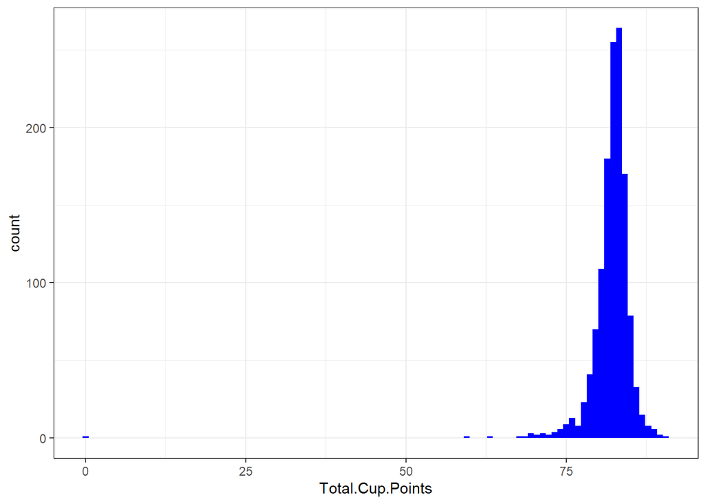

```r
ggplot(coffee,
       aes(x = Total.Cup.Points)) +
  geom_histogram(fill = "blue",
                 bins = 100) +
  theme_bw()
```

There is one outlier in Total.Cup.Points:

```r
coffee[which(coffee$Total.Cup.Points==0),]
```

```
## # A tibble: 1 x 36
##   Country.of.Orig~ Number.of.Bags Bag.Weight Variety Processing.Meth~ Aroma
##   <chr>                     <int> <fct>      <fct>   <fct>            <dbl>
## 1 Honduras                    275 >60        Caturra <NA>                 0
## # ... with 30 more variables: Flavor <dbl>, Aftertaste <dbl>, Acidity <dbl>,
## #   Body <dbl>, Balance <dbl>, Uniformity <dbl>, Clean.Cup <dbl>,
## #   Sweetness <dbl>, Cupper.Points <dbl>, Total.Cup.Points <dbl>,
## #   Moisture <dbl>, Category.One.Defects <int>, Quakers <dbl>, Color <chr>,
## #   Category.Two.Defects <int>, unit_of_measurement <chr>,
## #   altitude_low_meters <dbl>, altitude_high_meters <dbl>,
## #   altitude_mean_meters <dbl>, altitude_low_meters.impute_mean <dbl>,
## #   altitude_high_meters.impute_mean <dbl>,
## #   altitude_mean_meters.impute_mean <dbl>,
## #   altitude_low_meters.impute_median <dbl>,
## #   altitude_high_meters.impute_median <dbl>,
## #   altitude_mean_meters.impute_median <dbl>,
## #   Country.of.Origin.impute.Gmode <fct>, Region <fct>,
## #   Processing.Method.impute.Gmode <fct>, Color.impute.Gmode <fct>,
## #   Variety.impute.Gmode <fct>
```

The other numeric variables are equal to 0, so I delete this observation

```r
coffee <- coffee[-which(coffee$Total.Cup.Points==0),]
```

I create new dataframe without variables which I will not use in the analysis. I also delete Total.Cup.Points, because it is the sum of Aroma, Flavor, Aftertaste, Acidity, Body, Balance,Uniformity, Clean.Cup, Sweetness and Cupper.Points.

```r
coffee_final <- coffee
coffee_final[,c("Country.of.Origin","Processing.Method","Variety",
                "altitude_low_meters","altitude_high_meters",
             "altitude_mean_meters","Color","altitude_mean_meters.impute_mean",
             "altitude_low_meters.impute_mean",
             "altitude_high_meters.impute_mean","Total.Cup.Points")] <- NULL
```

Before split the dataset, I check if there are variables with zero or near zero variance, because such variables may need some tranformations.

```r
nearZeroVar(coffee_final,
            saveMetrics = TRUE) -> coffees_nzv_stats

coffees_nzv_stats %>%
  rownames_to_column("variable") %>%
  arrange(-zeroVar, -nzv, -freqRatio)
```

```
##                              variable freqRatio percentUnique zeroVar   nzv
## 1                             Quakers 31.179487     0.8396947   FALSE  TRUE
## 2                           Clean.Cup 20.586207     0.8396947   FALSE  TRUE
## 3                           Sweetness 19.967213     0.5343511   FALSE  TRUE
## 4                Category.One.Defects 10.990099     1.2213740   FALSE FALSE
## 5                          Uniformity 10.071429     0.6870229   FALSE FALSE
## 6                 unit_of_measurement  6.197802     0.1526718   FALSE FALSE
## 7                  Color.impute.Gmode  5.752577     0.1526718   FALSE FALSE
## 8  altitude_mean_meters.impute_median  4.121212    14.5038168   FALSE FALSE
## 9  altitude_high_meters.impute_median  4.046154    13.5114504   FALSE FALSE
## 10     Processing.Method.impute.Gmode  3.940239     0.3053435   FALSE FALSE
## 11  altitude_low_meters.impute_median  3.400000    13.5877863   FALSE FALSE
## 12               Category.Two.Defects  1.810000     2.9007634   FALSE FALSE
## 13                     Number.of.Bags  1.377143     9.9236641   FALSE FALSE
## 14                           Moisture  1.346290     1.7557252   FALSE FALSE
## 15                               Body  1.328859     2.2900763   FALSE FALSE
## 16     Country.of.Origin.impute.Gmode  1.295082     2.7480916   FALSE FALSE
## 17               Variety.impute.Gmode  1.211940     0.6106870   FALSE FALSE
## 18                            Balance  1.186207     2.3664122   FALSE FALSE
## 19                      Cupper.Points  1.117647     3.1297710   FALSE FALSE
## 20                         Aftertaste  1.080000     2.5954198   FALSE FALSE
## 21                            Acidity  1.066667     2.2900763   FALSE FALSE
## 22                              Aroma  1.061350     2.4427481   FALSE FALSE
## 23                             Region  1.046012     0.4580153   FALSE FALSE
## 24                         Bag.Weight  1.026385     0.3053435   FALSE FALSE
## 25                             Flavor  1.012346     2.5954198   FALSE FALSE
```

We havee 3 problematic variables

```r
table(coffee_final$Quakers)
```

```
##
##    0    1    2    3    4    5    6    7    8    9   11
## 1216   39   30    5    5    5    4    3    1    1    1
```

```r
table(coffee_final$Clean.Cup)
```

```
##
##    0 1.33 2.67 5.33    6 6.67 7.33    8 8.67 9.33   10
##    1    1    2    3    6   13    3   13   16   58 1194
```

```r
table(coffee_final$Sweetness)
```

```
##
## 1.33    6 6.67    8 8.67 9.33   10
##    1    3    7    8   12   61 1218
```

I will group them in two groups, because in each column there is one hugly dominant value.

```r
quakers_not_zero_train <- which(coffee_final$Quakers>0)
coffee_final$Quakers <- as.character(coffee_final$Quakers)
coffee_final[quakers_not_zero_train,"Quakers"] <- ">0"
coffee_final$Quakers <- as.factor(coffee_final$Quakers)
table(coffee_final$Quakers)
```

```
##
##   >0    0
##   94 1216
```

```r
clean_cup_not_10_train <- which(coffee_final$Clean.Cup<10)
coffee_final$Clean.Cup <- as.character(coffee_final$Clean.Cup)
coffee_final[clean_cup_not_10_train,"Clean.Cup"] <- "<10"
coffee_final$Clean.Cup <- as.factor(coffee_final$Clean.Cup)
table(coffee_final$Clean.Cup)
```

```
##
##  <10   10
##  116 1194
```

```r
sweetness_not_10_train <- which(coffee_final$Sweetness<10)
coffee_final$Sweetness <- as.character(coffee_final$Sweetness)
coffee_final[sweetness_not_10_train,"Sweetness"] <- "<10"
coffee_final$Sweetness <- as.factor(coffee_final$Sweetness)
table(coffee_final$Sweetness)
```

```
##
##  <10   10
##   92 1218
```

Let’s check if they have still near zero variance:

```r
nearZeroVar(coffee_final,
            saveMetrics = TRUE) -> coffees_nzv_stats

coffees_nzv_stats %>%
  rownames_to_column("variable") %>%
  arrange(-zeroVar, -nzv, -freqRatio)
```

```
##                              variable freqRatio percentUnique zeroVar   nzv
## 1                           Sweetness 13.239130     0.1526718   FALSE FALSE
## 2                             Quakers 12.936170     0.1526718   FALSE FALSE
## 3                Category.One.Defects 10.990099     1.2213740   FALSE FALSE
## 4                           Clean.Cup 10.293103     0.1526718   FALSE FALSE
## 5                          Uniformity 10.071429     0.6870229   FALSE FALSE
## 6                 unit_of_measurement  6.197802     0.1526718   FALSE FALSE
## 7                  Color.impute.Gmode  5.752577     0.1526718   FALSE FALSE
## 8  altitude_mean_meters.impute_median  4.121212    14.5038168   FALSE FALSE
## 9  altitude_high_meters.impute_median  4.046154    13.5114504   FALSE FALSE
## 10     Processing.Method.impute.Gmode  3.940239     0.3053435   FALSE FALSE
## 11  altitude_low_meters.impute_median  3.400000    13.5877863   FALSE FALSE
## 12               Category.Two.Defects  1.810000     2.9007634   FALSE FALSE
## 13                     Number.of.Bags  1.377143     9.9236641   FALSE FALSE
## 14                           Moisture  1.346290     1.7557252   FALSE FALSE
## 15                               Body  1.328859     2.2900763   FALSE FALSE
## 16     Country.of.Origin.impute.Gmode  1.295082     2.7480916   FALSE FALSE
## 17               Variety.impute.Gmode  1.211940     0.6106870   FALSE FALSE
## 18                            Balance  1.186207     2.3664122   FALSE FALSE
## 19                      Cupper.Points  1.117647     3.1297710   FALSE FALSE
## 20                         Aftertaste  1.080000     2.5954198   FALSE FALSE
## 21                            Acidity  1.066667     2.2900763   FALSE FALSE
## 22                              Aroma  1.061350     2.4427481   FALSE FALSE
## 23                             Region  1.046012     0.4580153   FALSE FALSE
## 24                         Bag.Weight  1.026385     0.3053435   FALSE FALSE
## 25                             Flavor  1.012346     2.5954198   FALSE FALSE
```

There are no near zero variance variables now.

## 2.3 Data division

Now let’s divide the set into learning and testing sample

```r
set.seed(987654321)

coffees_which_train <- createDataPartition(coffee_final$Cupper.Points,
                                          p = 0.7,
                                          list = FALSE)
head(coffees_which_train)
```

```
##      Resample1
## [1,]         1
## [2,]         3
## [3,]         4
## [4,]         6
## [5,]         8
## [6,]         9
```

```r
coffees_train <- coffee_final[coffees_which_train,]
coffees_test <- coffee_final[-coffees_which_train,]
```

The distributions of the target variable in both samples are similar:

```r
summary(coffees_train$Cupper.Points)
```

```
##    Min. 1st Qu.  Median    Mean 3rd Qu.    Max.
##   5.170   7.250   7.500   7.506   7.750  10.000
```

```r
summary(coffees_test$Cupper.Points)
```

```
##    Min. 1st Qu.  Median    Mean 3rd Qu.    Max.
##   6.170   7.250   7.500   7.499   7.750  10.000
```

Storing the list of names of numeric variables into a vector:

```r
coffees_numeric_vars <-
  sapply(coffees_train, is.numeric) %>%
  which() %>%
  names()

coffees_numeric_vars
```

```
##  [1] "Number.of.Bags"                     "Aroma"
##  [3] "Flavor"                             "Aftertaste"
##  [5] "Acidity"                            "Body"
##  [7] "Balance"                            "Uniformity"
##  [9] "Cupper.Points"                      "Moisture"
## [11] "Category.One.Defects"               "Category.Two.Defects"
## [13] "altitude_low_meters.impute_median"  "altitude_high_meters.impute_median"
## [15] "altitude_mean_meters.impute_median"
```

## 2.4 Correlation

Mutually correlated variables:

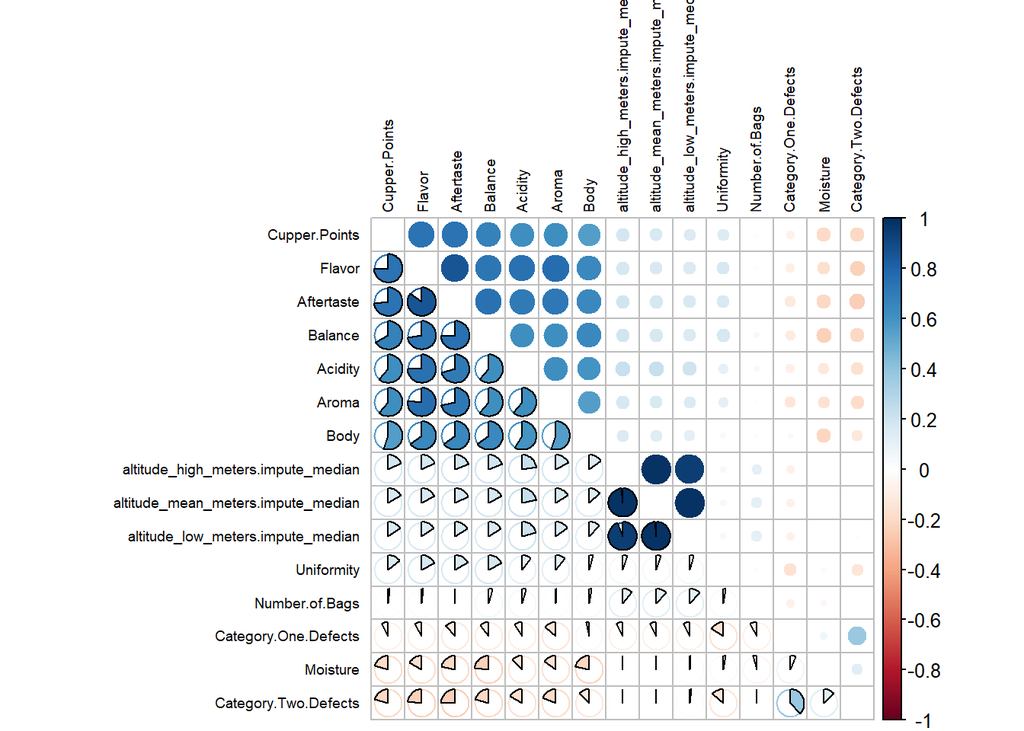

```r
coffee_correlations <-
  cor(coffees_train[,coffees_numeric_vars],
      use = "pairwise.complete.obs")

coffees_numeric_vars_order <-
  coffee_correlations[,"Cupper.Points"] %>%
  sort(decreasing = TRUE) %>%
  names()

corrplot.mixed(coffee_correlations[coffees_numeric_vars_order,
                                   coffees_numeric_vars_order],
               upper = "circle",
               lower = "pie",
               tl.col="black",
               tl.pos = "lt",
               tl.cex = 0.6)
```

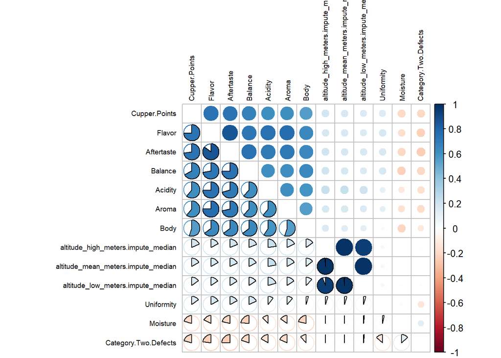

```r
corrplot.mixed(coffee_correlations[coffees_numeric_vars_order[-12:-13],
                                   coffees_numeric_vars_order[-12:-13]],
               upper = "circle",
               lower = "pie",
               tl.col = "black",
               tl.pos = "lt",
               tl.cex = 0.6)
```

## Variables relationships

The relation of the target variable with the most strongly correlated variables - Flavour:

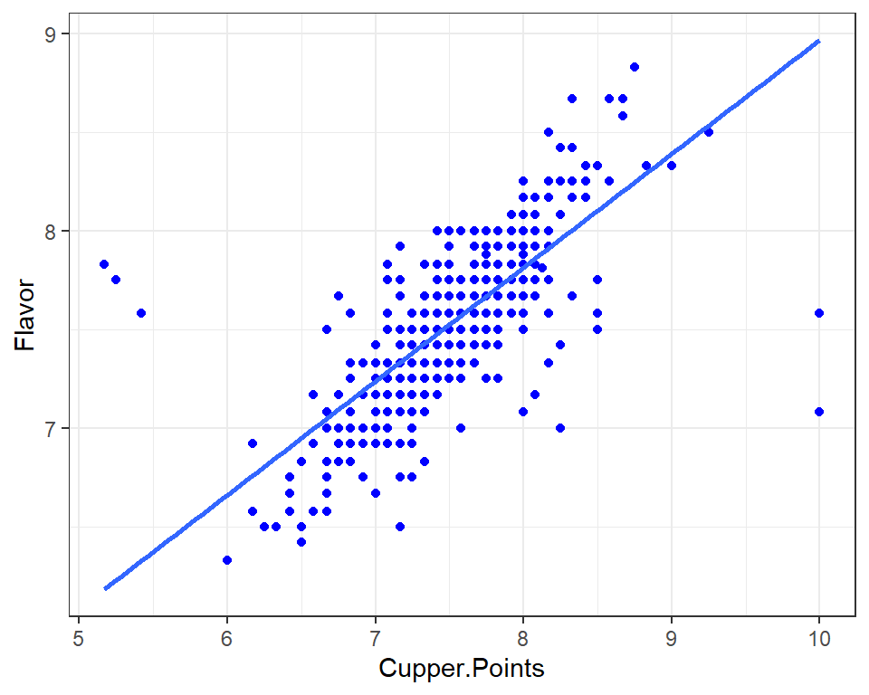

```r
ggplot(coffees_train,
       aes(x = Cupper.Points,
           y = Flavor)) +
  geom_point(col = "blue") +
  geom_smooth(method = "lm", se = FALSE) +
  theme_bw()
```

5 coffees clearly not matching the relationship - 2 coffees with the flavour < 8, but Cupper.Points = 10. 3 coffees with Cupper.Points < 5.5 and Flavor > 7.5. Maybe exclude these observations from the sample.

```r
coffees_outliers <- NULL
coffees_outliers_flavor <- which(coffees_train$Flavor < 8 &
                                   coffees_train$Cupper.Points == 10)
coffees_outliers_flavor <- append(coffees_outliers_flavor,
                                  which(coffees_train$Flavor > 7.5 &
                                          coffees_train$Cupper.Points < 5.5))

coffees_outliers <- append(coffees_outliers,coffees_outliers_flavor)
```

Aftertaste:

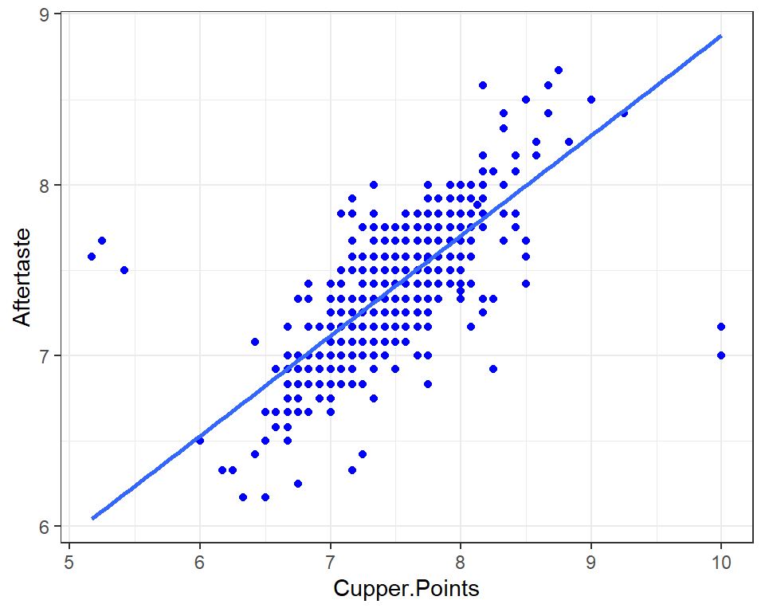

```r
ggplot(coffees_train,
       aes(x = Cupper.Points,
           y = Aftertaste)) +
  geom_point(col = "blue") +
  geom_smooth(method = "lm", se = FALSE) +
  theme_bw()
```

5 coffees clearly notmatching the relationship - they look similar to the previous values from Flavor.

```r
coffees_outliers_aftertaste <- which(coffees_train$Aftertaste >= 7.5 &
                                       coffees_train$Cupper.Points < 5.5)
coffees_outliers_aftertaste <- append(coffees_outliers_aftertaste,
                                      which(coffees_train$Aftertaste < 8 &
                                              coffees_train$Cupper.Points == 10))
identical(sort(coffees_outliers_flavor),sort(coffees_outliers_aftertaste))
```

```
## [1] TRUE
```

They were exactly the same outliers.

Balance:

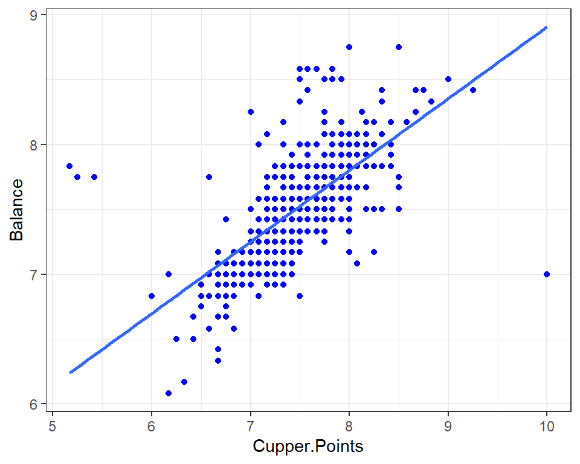

```r
ggplot(coffees_train,
       aes(x = Cupper.Points,
           y = Balance)) +
  geom_point(col = "blue") +
  geom_smooth(method = "lm", se = FALSE) +
  theme_bw()
```

```r
coffees_outliers_balance <- which(coffees_train$Balance == 7 &
                                    coffees_train$Cupper.Points == 10)
# Actually there are 2 outliers with exact value of Balance and Cupper.Points
coffees_outliers_balance <- append(coffees_outliers_balance,
                                   which(coffees_train$Balance > 7.5 &
                                           coffees_train$Cupper.Points < 5.5))
identical(sort(coffees_outliers_flavor),sort(coffees_outliers_balance))
```

```
## [1] TRUE
```

They were exactly the same outliers.

Aroma:

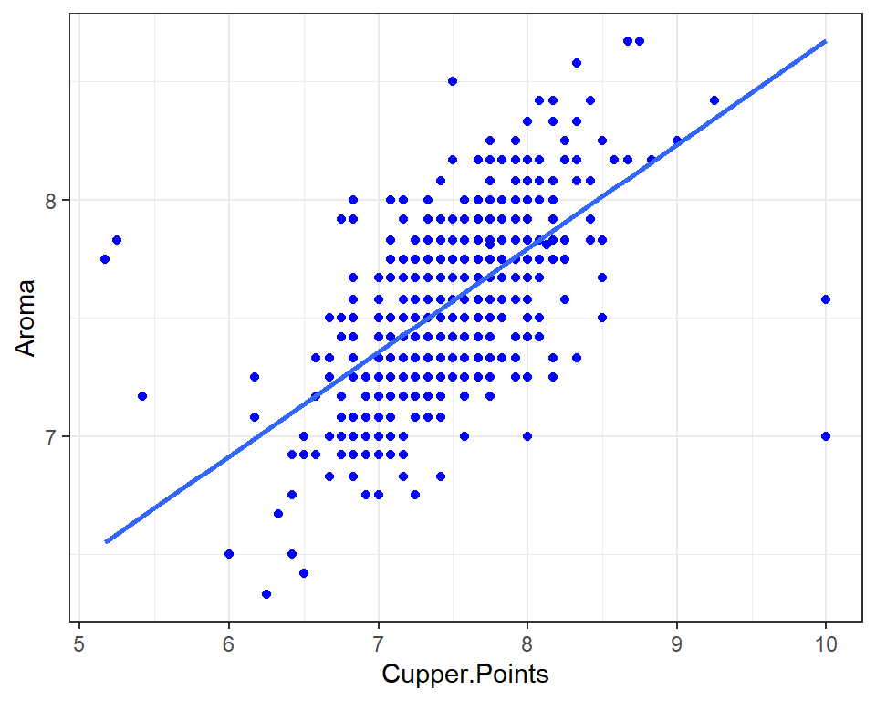

```r
ggplot(coffees_train,
       aes(x = Cupper.Points,
           y = Aroma)) +
  geom_point(col = "blue") +
  geom_smooth(method = "lm", se = FALSE) +
  theme_bw()
```

```r
coffees_outliers_aroma <- which(coffees_train$Aroma < 7.75 &
                                  coffees_train$Cupper.Points == 10)
coffees_outliers_aroma <- append(coffees_outliers_aroma,
                                   which(coffees_train$Aroma > 7.5 &
                                           coffees_train$Cupper.Points < 5.5))
```

These outliers were marked earlier.

Acidity:

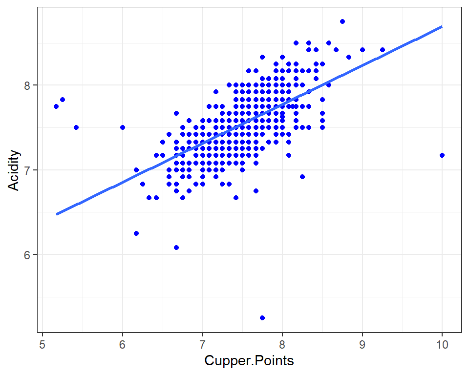

```r
ggplot(coffees_train,
       aes(x = Cupper.Points,
           y = Acidity)) +
  geom_point(col = "blue") +
  geom_smooth(method = "lm", se = FALSE) +
  theme_bw()
```

At least 2 clear outliers.

```r
which(coffees_train$Acidity < 7.5 & coffees_train$Cupper.Points == 10)
```

```
## [1] 249 520
```

```r
# 2 outliers marked earlier
coffees_outliers_acidity <- which(coffees_train$Acidity < 5.5 &
                                    coffees_train$Cupper.Points > 7.5)
# 1 new outlier
coffees_outliers <- append(coffees_outliers,coffees_outliers_acidity)
```

Body:

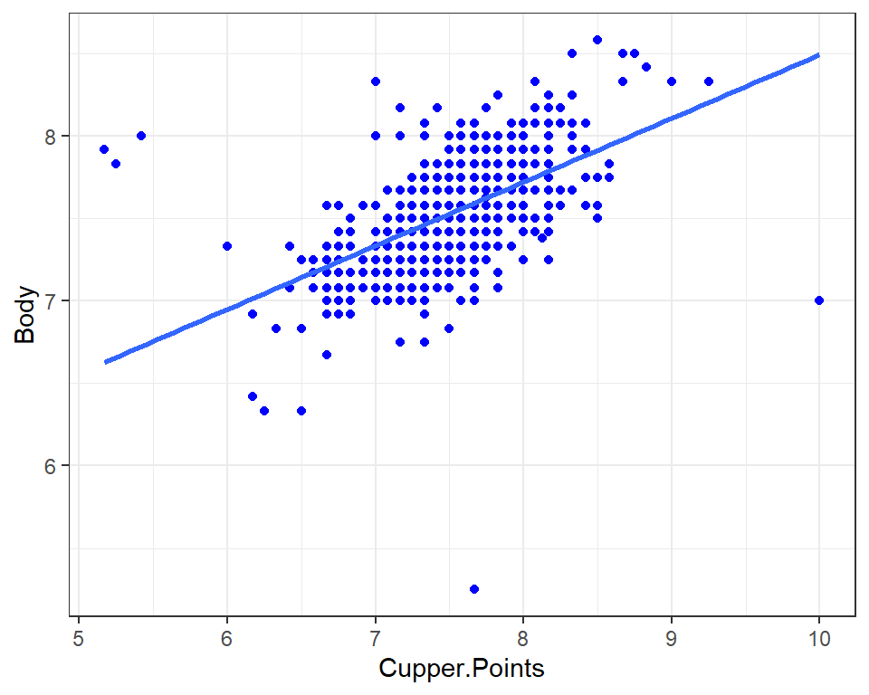

```r
ggplot(coffees_train,
       aes(x = Cupper.Points,
           y = Body)) +
  geom_point(col = "blue") +
  geom_smooth(method = "lm", se = FALSE) +
  theme_bw()
```

```r
#At least 2 clear outliers
#which(coffees_train$Body == 7 & coffees_train$Cupper.Points == 10)
# 2 outliers marked earlier
coffees_outliers_body <- which(coffees_train$Body < 5.5 &
                                 coffees_train$Cupper.Points > 7.5)
# 1 new outlier
coffees_outliers <- append(coffees_outliers,coffees_outliers_body)
```

Uniformity:

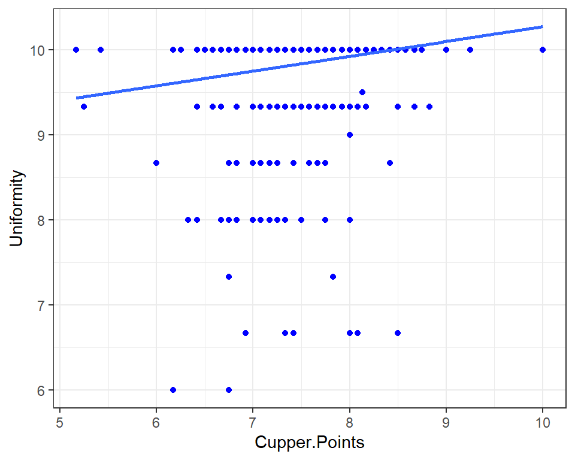

```r
ggplot(coffees_train,
       aes(x = Cupper.Points,
           y = Uniformity)) +
  geom_point(col = "blue") +
  geom_smooth(method = "lm", se = FALSE) +
  theme_bw()
```

Relationship looks more like relationship with categorical variable.

Moisture:

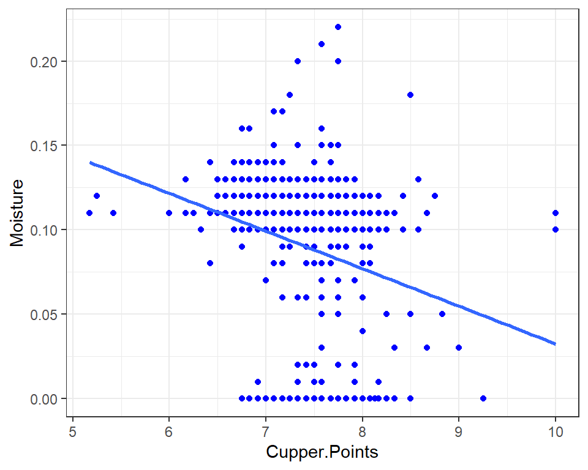

```r
ggplot(coffees_train,
       aes(x = Cupper.Points,
           y = Moisture)) +
  geom_point(col = "blue") +
  geom_smooth(method = "lm", se = FALSE) +
  theme_bw()
```

Many values far from relationship.

Category.One.Defects:

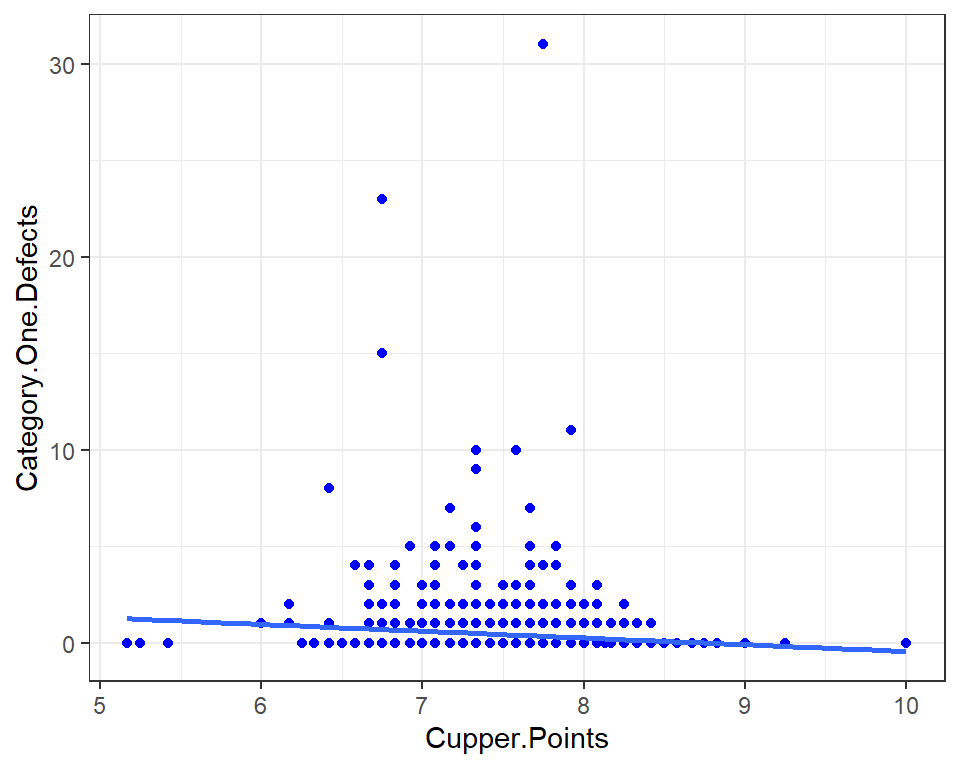

```r
ggplot(coffees_train,
       aes(x = Cupper.Points,
           y = Category.One.Defects)) +
  geom_point(col = "blue") +
  geom_smooth(method = "lm", se = FALSE) +
  theme_bw()
```

3 clear outliers - Defects >= 15 and Cupper.Points above 6.5.

```r
coffees_outliers_cat1_defects <- which(coffees_train$Category.One.Defects >= 15 &
                                         coffees_train$Cupper.Points > 6.5)
coffees_outliers <- append(coffees_outliers,coffees_outliers_cat1_defects)
```

Altitude_mean_meters.impute_median:

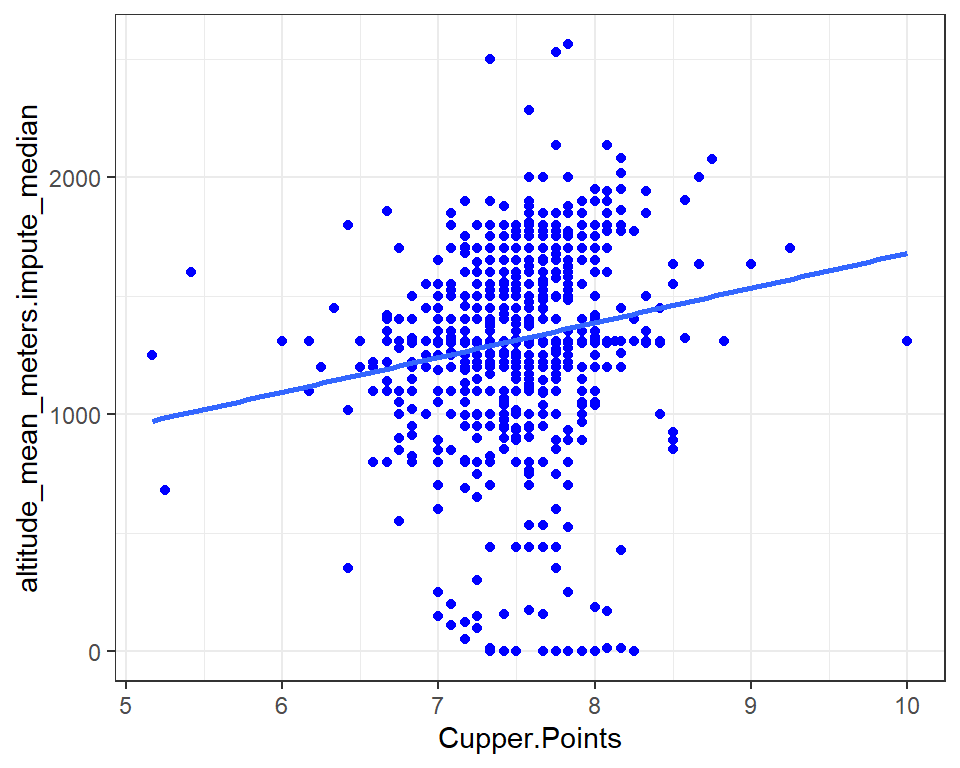

```r
ggplot(coffees_train,
       aes(x = Cupper.Points,
           y = altitude_mean_meters.impute_median)) +
  geom_point(col = "blue") +
  geom_smooth(method = "lm", se = FALSE) +
  theme_bw()
```

There is some positive relationship, but very unclear - many values far from relationship.

Now I try to find highly correlated variables:

```r
findCorrelation(coffee_correlations,
                cutoff = 0.80,
                names = TRUE)
```

```
## [1] "Aftertaste"                         "altitude_high_meters.impute_median"
## [3] "altitude_low_meters.impute_median"
```

These variables are potential candidates to be excluded from the model because of the high correlation between them.

```r
coffees_categorical_vars <-
  sapply(coffees_train, is.factor) %>%
  which() %>%
  names()

coffees_categorical_vars
```

```
## [1] "Bag.Weight"                     "Clean.Cup"
## [3] "Sweetness"                      "Quakers"
## [5] "Country.of.Origin.impute.Gmode" "Region"
## [7] "Processing.Method.impute.Gmode" "Color.impute.Gmode"
## [9] "Variety.impute.Gmode"
```

I use the function that retrieves F statistic value for the explanatory categorical variable provided as the function argument.

```r
coffees_F_anova <- function(categorical_var) {
  anova_ <- aov(coffees_train$Cupper.Points ~
                  coffees_train[[categorical_var]])

  return(summary(anova_)[[1]][1, 4])
}
```

Relationship between coffees_categorical_vars and Cupper.Points:

```r
sapply(coffees_categorical_vars,
       coffees_F_anova) %>%
  sort(decreasing = TRUE) -> coffees_anova_all_categorical

coffees_anova_all_categorical
```

```
##                      Clean.Cup             Color.impute.Gmode
##                     45.5452462                     18.1382503
##                         Region                     Bag.Weight
##                     17.0062764                     12.9751893
## Country.of.Origin.impute.Gmode           Variety.impute.Gmode
##                      6.2321289                      3.2669334
## Processing.Method.impute.Gmode                      Sweetness
##                      2.1798322                      1.4017320
##                        Quakers
##                      0.3713259
```

Relation between Color.impute.Gmode levels and Cupper.Points:

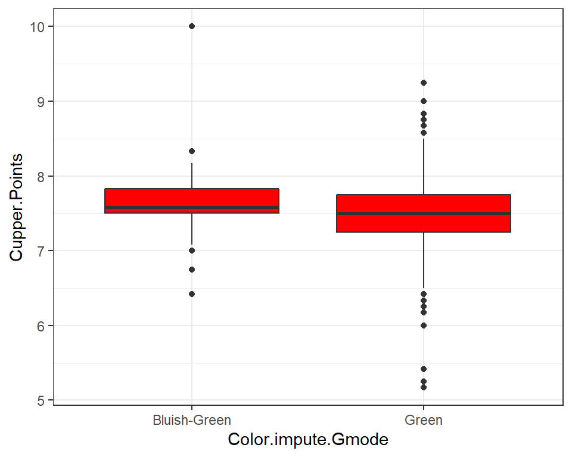

```r
ggplot(coffees_train,
       aes(x = Color.impute.Gmode,
           y = Cupper.Points)) +
  geom_boxplot(fill = "red") +
  theme_bw()
```

Green has many outliers. Bluish-Green has slightly higher values.

Relation between Country.of.Origin.impute.Gmode levels and Cupper.Points:

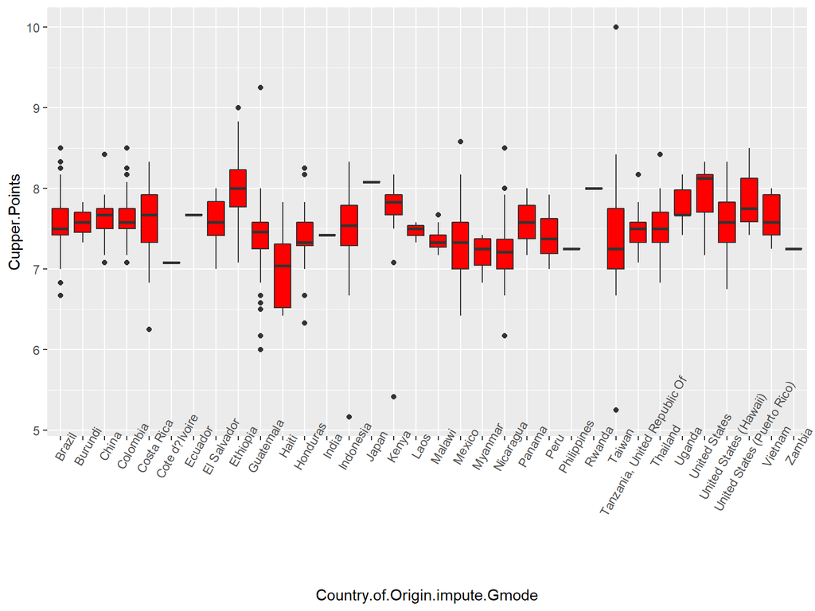

```r
ggplot(coffees_train,
       aes(x = Country.of.Origin.impute.Gmode,
           y = Cupper.Points)) +
  geom_boxplot(fill = "red") +
  theme(axis.text.x = element_text(angle = 60))
```

There can be seen some relationships between these variables but there are countries with only few coffees. Thus, we probably choose the region.

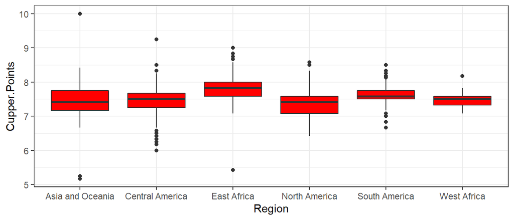

```r
ggplot(coffees_train,
       aes(x = Region,
           y = Cupper.Points)) +
  geom_boxplot(fill = "red") +
  theme_bw()
```

It can be seen that there are differences between Regions.

The relationship between Cupper.Points and Variety.impute.Gmode:

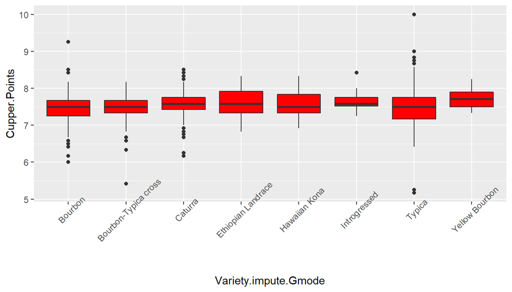

```r
ggplot(coffees_train,
       aes(x = Variety.impute.Gmode,
           y = Cupper.Points)) +
  geom_boxplot(fill = "red") +
  theme(axis.text.x = element_text(angle = 45))
```

There are some differences between varieties of coffee, but not very clear.

The relationship between Cupper.Points and Processing.Method.impute.Gmode:

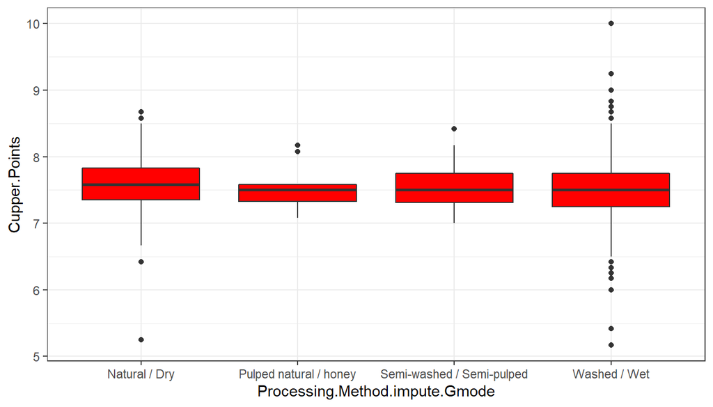

```r
ggplot(coffees_train,
       aes(x = Processing.Method.impute.Gmode,
           y = Cupper.Points)) +
  geom_boxplot(fill = "red") +
  theme_bw()
```

There is no clear differences betweend processing methods. There are many values far from mean and median in Washed / Wet.

The relationship between Cupper.Points and Clean.Cup:

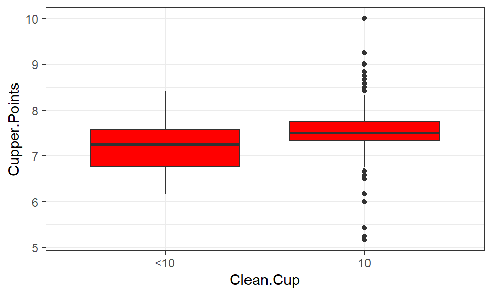

```r
ggplot(coffees_train,
       aes(x = Clean.Cup,
           y = Cupper.Points)) +
  geom_boxplot(fill = "red") +
  theme_bw()
```

Clean.Cup = 10 has higher values than <10, but also many outliers there.

The relationship between Cupper.Points and Sweetness:

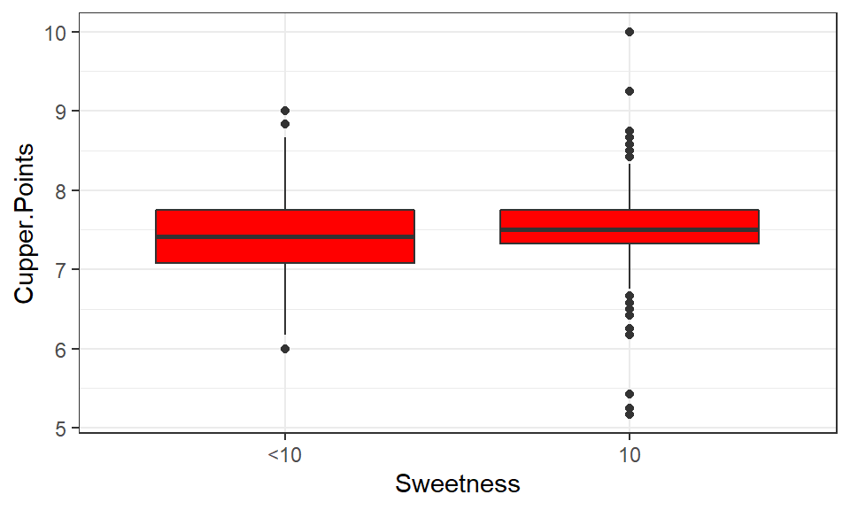

```r
ggplot(coffees_train,
       aes(x = Sweetness,
           y = Cupper.Points)) +
  geom_boxplot(fill = "red") +
  theme_bw()
```

Sweetness = 10 has slightly higher values than <10, but also many outliers there.

The relationship between Cupper.Points and Quakers:

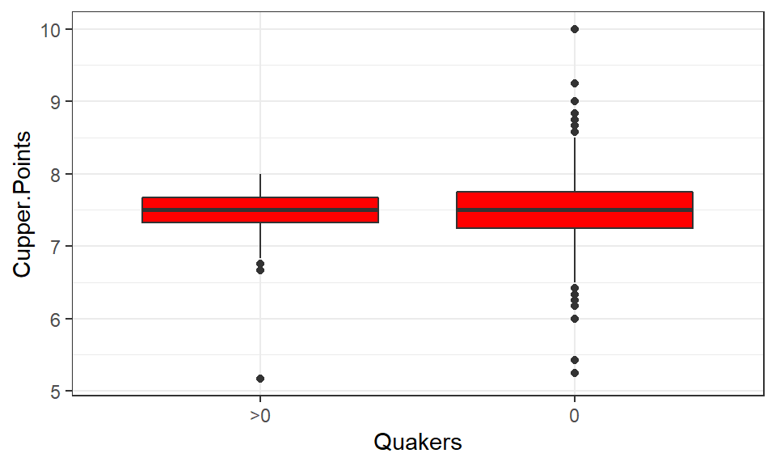

```r
ggplot(coffees_train,
       aes(x = Quakers,
           y = Cupper.Points)) +
  geom_boxplot(fill = "red") +
  theme_bw()
```

Very Similar mean and similar distributions, but many outliers for Quakers = 0.

The relationship between Cupper.Points and unit_of_measurement.

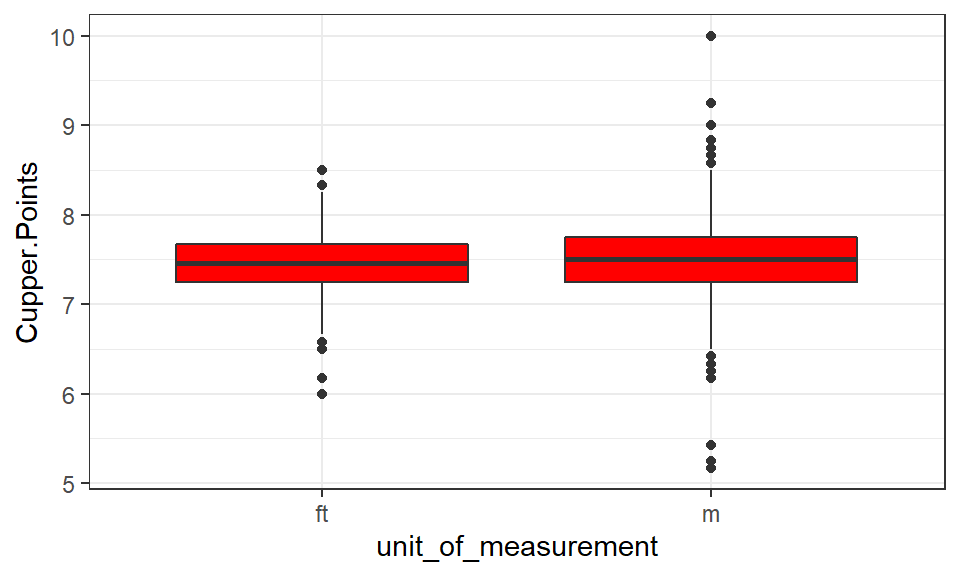

```r
ggplot(coffees_train,
       aes(x = unit_of_measurement,
           y = Cupper.Points)) +
  geom_boxplot(fill = "red") +
  theme_bw()
```

The relationship between Cupper.Points and Bag.Weight

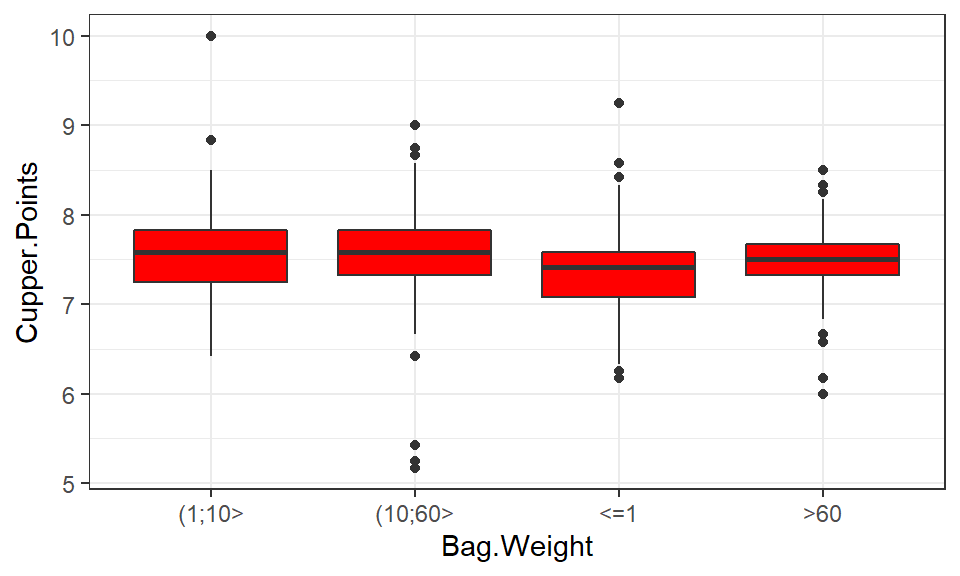

```r
ggplot(coffees_train,
       aes(x = Bag.Weight,
           y = Cupper.Points)) +
  geom_boxplot(fill = "red") +
  theme_bw()
```

There are diffrences between Bag.Weights, but not so big.

Bag.Weight and unit_of_measurement can be also higly correlated with Processing_method and Region. Let’s check it with the Cramer’s V coefficient.

```r
DescTools::CramerV(coffees_train$unit_of_measurement,
                   coffees_train$Region)
```

```
## [1] 0.368987
```

Moderate association between unit_of_measurement and Region.

```r
DescTools::CramerV(coffees_train$unit_of_measurement,
                   coffees_train$Processing.Method.impute.Gmode)
```

```
## [1] 0.1128418
```

Low association between unit_of_measurement and Processing.Method.impute.Gmode.

```r
DescTools::CramerV(coffees_train$Bag.Weight,
                   coffees_train$Region)
```

```
## [1] 0.4782707
```

Moderate association between Bag.Weight and Region.

```r
DescTools::CramerV(coffees_train$Bag.Weight,
                   coffees_train$Processing.Method.impute.Gmode)
```

```
## [1] 0.2201453
```

Low association between Bag.Weight and Processing.Method.impute.Gmode.

```r
DescTools::CramerV(coffees_train$Bag.Weight,
                   coffees_train$unit_of_measurement)
```

```
## [1] 0.1635196
```

Low association between Bag.Weight and unit_of_measurement.

There is moderate association between Bag.Weight and Region and also between unit_of_measurement and Region. I do not exclude them from the analysis for now.

I check if there is some linear combination of other variables

```r
( findLinearCombos(coffees_train[, coffees_numeric_vars] ) ->
    coffees_linearCombos )
```

```
## $linearCombos
## list()
##
## $remove
## NULL
```

There is no such combination.

Now i prepare vector of coffee variables names.

```r
#all coffees_train variables
coffees_variables_all <- names(coffees_train)
```

Altitudes are very highly correlated to each other, so I choose only altitude_mean_meters.impute_median.

```r
coffees_variables_all <-
  coffees_variables_all[!coffees_variables_all %in%
                          c("altitude_low_meters.impute_median",
                            "altitude_high_meters.impute_median",
                            "Category.One.Defects",
                            "Number.of.Bags")]
```

Now I delete outliers form training set.

```r
coffees_train <- coffees_train[-coffees_outliers,]

options(contrasts = c("contr.treatment",
                      "contr.treatment"))
```

# 3 Data modelling

## 3.1 Linear model

Estimation of the model with all variables:

```r
coffees_lm1 <- lm(Cupper.Points ~ .,
                 data = coffees_train %>%
                   dplyr::select(all_of(coffees_variables_all)))


summary(coffees_lm1)
```

```
##
## Call:
## lm(formula = Cupper.Points ~ ., data = coffees_train %>% dplyr::select(all_of(coffees_variables_all)))
##
## Residuals:
##      Min       1Q   Median       3Q      Max
## -0.56264 -0.09494 -0.00819  0.08739  0.90802
##
## Coefficients: (5 not defined because of singularities)
##                                                              Estimate
## (Intercept)                                                -9.470e-01
## Bag.Weight(10;60>                                          -2.188e-02
## Bag.Weight<=1                                              -3.852e-02
## Bag.Weight>60                                               1.925e-02
## Aroma                                                       4.435e-02
## Flavor                                                      3.331e-01
## Aftertaste                                                  2.447e-01
## Acidity                                                     1.554e-01
## Body                                                        1.003e-01
## Balance                                                     2.615e-01
## Uniformity                                                 -1.863e-02
## Clean.Cup10                                                 6.987e-02
## Sweetness10                                                 8.083e-03
## Moisture                                                   -1.747e-01
## Quakers0                                                    9.811e-03
## Category.Two.Defects                                       -2.184e-03
## unit_of_measurementm                                        7.870e-02
## altitude_mean_meters.impute_median                         -3.853e-06
## Country.of.Origin.impute.GmodeBurundi                       2.065e-01
## Country.of.Origin.impute.GmodeChina                         7.969e-02
## Country.of.Origin.impute.GmodeColombia                     -8.104e-02
## Country.of.Origin.impute.GmodeCosta Rica                    6.509e-02
## Country.of.Origin.impute.GmodeCote d?Ivoire                 3.801e-02
## Country.of.Origin.impute.GmodeEcuador                      -1.544e-01
## Country.of.Origin.impute.GmodeEl Salvador                  -1.248e-01
## Country.of.Origin.impute.GmodeEthiopia                      1.285e-02
## Country.of.Origin.impute.GmodeGuatemala                    -5.601e-02
## Country.of.Origin.impute.GmodeHaiti                         3.151e-03
## Country.of.Origin.impute.GmodeHonduras                     -9.697e-03
## Country.of.Origin.impute.GmodeIndia                         1.894e-01
```

[output cut: 164 more lines]

```
## Processing.Method.impute.GmodeWashed / Wet                 0.168967
## Color.impute.GmodeGreen                                    0.768804
## Variety.impute.GmodeBourbon-Typica cross                   0.608025
## Variety.impute.GmodeCaturra                                0.217417
## Variety.impute.GmodeEthiopian Landrace                     0.340975
## Variety.impute.GmodeHawaiian Kona                          0.621281
## Variety.impute.GmodeIntrogressed                           0.512272
## Variety.impute.GmodeTypica                                 0.765570
## Variety.impute.GmodeYellow Bourbon                         0.005176 **
## ---
## Signif. codes:  0 '***' 0.001 '**' 0.01 '*' 0.05 '.' 0.1 ' ' 1
##
## Residual standard error: 0.1802 on 846 degrees of freedom
## Multiple R-squared:  0.8047, Adjusted R-squared:  0.7906
## F-statistic: 57.13 on 61 and 846 DF,  p-value: < 2.2e-16
```

There are some missing coefficients.

```r
coef(coffees_lm1)[is.na(coef(coffees_lm1))]
```

```
## RegionCentral America     RegionEast Africa   RegionNorth America
##                    NA                    NA                    NA
##   RegionSouth America     RegionWest Africa
##                    NA                    NA
```

Unfortunately all of Region dummies seems to be multicollinear. Thus, I create new vector without these variables.

```r
coffees_variables_all2 <-
  coffees_variables_all[-which(coffees_variables_all %in%
                                c("Region","Country.of.Origin.impute.Gmode"))]

coffees_lm2 <- lm(Cupper.Points ~ .,
                  data = coffees_train %>%
                    dplyr::select(all_of(coffees_variables_all2)))

summary(coffees_lm2)
```

```
##
## Call:
## lm(formula = Cupper.Points ~ ., data = coffees_train %>% dplyr::select(all_of(coffees_variables_all2)))
##
## Residuals:
##      Min       1Q   Median       3Q      Max
## -0.62803 -0.09817 -0.01219  0.08784  0.92866
##
## Coefficients:
##                                                           Estimate Std. Error
## (Intercept)                                             -9.160e-01  2.373e-01
## Bag.Weight(10;60>                                       -2.097e-02  2.185e-02
## Bag.Weight<=1                                           -3.130e-02  2.223e-02
## Bag.Weight>60                                           -2.330e-02  2.349e-02
## Aroma                                                    4.407e-02  3.255e-02
## Flavor                                                   3.309e-01  4.257e-02
## Aftertaste                                               2.550e-01  3.928e-02
## Acidity                                                  1.459e-01  3.357e-02
## Body                                                     1.044e-01  3.293e-02
## Balance                                                  2.592e-01  2.921e-02
## Uniformity                                              -2.359e-02  1.556e-02
## Clean.Cup10                                              6.265e-02  2.901e-02
## Sweetness10                                              1.863e-02  2.740e-02
## Moisture                                                -9.120e-02  1.393e-01
## Quakers0                                                 1.419e-03  2.524e-02
## Category.Two.Defects                                    -1.724e-03  1.347e-03
## unit_of_measurementm                                     6.416e-02  2.238e-02
## altitude_mean_meters.impute_median                       1.718e-05  1.872e-05
## Processing.Method.impute.GmodePulped natural / honey    -3.261e-02  6.510e-02
## Processing.Method.impute.GmodeSemi-washed / Semi-pulped -5.453e-02  3.397e-02
## Processing.Method.impute.GmodeWashed / Wet              -2.452e-02  1.808e-02
## Color.impute.GmodeGreen                                 -6.655e-03  1.847e-02
## Variety.impute.GmodeBourbon-Typica cross                 1.961e-04  2.367e-02
## Variety.impute.GmodeCaturra                              1.768e-02  1.954e-02
## Variety.impute.GmodeEthiopian Landrace                   5.872e-02  5.085e-02
## Variety.impute.GmodeHawaiian Kona                        4.381e-02  4.230e-02
## Variety.impute.GmodeIntrogressed                         4.286e-02  4.662e-02
## Variety.impute.GmodeTypica                              -4.214e-03  1.842e-02
## Variety.impute.GmodeYellow Bourbon                       1.642e-01  4.510e-02
##                                                         t value Pr(>|t|)
```

[output cut: 20 more lines]

```
## Processing.Method.impute.GmodeWashed / Wet               -1.356 0.175300
## Color.impute.GmodeGreen                                  -0.360 0.718678
## Variety.impute.GmodeBourbon-Typica cross                  0.008 0.993393
## Variety.impute.GmodeCaturra                               0.905 0.365867
## Variety.impute.GmodeEthiopian Landrace                    1.155 0.248529
## Variety.impute.GmodeHawaiian Kona                         1.036 0.300568
## Variety.impute.GmodeIntrogressed                          0.919 0.358181
## Variety.impute.GmodeTypica                               -0.229 0.819134
## Variety.impute.GmodeYellow Bourbon                        3.640 0.000288 ***
## ---
## Signif. codes:  0 '***' 0.001 '**' 0.01 '*' 0.05 '.' 0.1 ' ' 1
##
## Residual standard error: 0.1836 on 879 degrees of freedom
## Multiple R-squared:  0.7894, Adjusted R-squared:  0.7827
## F-statistic: 117.7 on 28 and 879 DF,  p-value: < 2.2e-16
```

Now I run Backward Elimination based on p-value 0.1 on both models:

```r
coffees_lm_backward_1 <-
  ols_step_backward_p(coffees_lm1,
                      prem = 0.1,
                      progress = FALSE)
```

[output not shown]

```r
coffees_lm_backward_2 <-
  ols_step_backward_p(coffees_lm2,
                      prem = 0.1,
                      progress = FALSE)
```

Final model details:

```r
summary(coffees_lm_backward_1$model)
```

```
##
## Call:
## lm(formula = paste(response, "~", paste(preds, collapse = " + ")),
##     data = l)
##
## Residuals:
##      Min       1Q   Median       3Q      Max
## -0.54991 -0.09442 -0.01003  0.08757  0.96529
##
## Coefficients: (5 not defined because of singularities)
##                                                             Estimate Std. Error
## (Intercept)                                                -1.122019   0.199545
## Bag.Weight(10;60>                                          -0.026594   0.025067
## Bag.Weight<=1                                              -0.042519   0.026362
## Bag.Weight>60                                               0.016014   0.025416
## Flavor                                                      0.358996   0.040837
## Aftertaste                                                  0.254188   0.039593
## Acidity                                                     0.156435   0.034185
## Body                                                        0.107490   0.032847
## Balance                                                     0.261734   0.029117
## Clean.Cup10                                                 0.053708   0.023257
## unit_of_measurementm                                        0.076239   0.030172
## Country.of.Origin.impute.GmodeBurundi                       0.196003   0.130321
## Country.of.Origin.impute.GmodeChina                         0.055536   0.075688
## Country.of.Origin.impute.GmodeColombia                     -0.085835   0.040232
## Country.of.Origin.impute.GmodeCosta Rica                    0.052797   0.041509
## Country.of.Origin.impute.GmodeCote d?Ivoire                 0.039735   0.184631
## Country.of.Origin.impute.GmodeEcuador                      -0.152482   0.183998
## Country.of.Origin.impute.GmodeEl Salvador                  -0.137930   0.058312
## Country.of.Origin.impute.GmodeEthiopia                     -0.004584   0.045770
## Country.of.Origin.impute.GmodeGuatemala                    -0.071272   0.040095
## Country.of.Origin.impute.GmodeHaiti                        -0.019230   0.081816
## Country.of.Origin.impute.GmodeHonduras                     -0.025137   0.043748
## Country.of.Origin.impute.GmodeIndia                         0.233783   0.184553
## Country.of.Origin.impute.GmodeIndonesia                     0.011733   0.056062
## Country.of.Origin.impute.GmodeJapan                         0.301269   0.185199
## Country.of.Origin.impute.GmodeKenya                        -0.034390   0.049571
## Country.of.Origin.impute.GmodeLaos                          0.084555   0.116435
## Country.of.Origin.impute.GmodeMalawi                       -0.035505   0.081914
## Country.of.Origin.impute.GmodeMexico                       -0.017980   0.038741
```

[output cut: 75 more lines]

```
## RegionSouth America                                             NA       NA
## RegionWest Africa                                               NA       NA
## Variety.impute.GmodeBourbon-Typica cross                    -0.655  0.51266
## Variety.impute.GmodeCaturra                                  1.253  0.21070
## Variety.impute.GmodeEthiopian Landrace                       1.047  0.29559
## Variety.impute.GmodeHawaiian Kona                           -0.461  0.64480
## Variety.impute.GmodeIntrogressed                            -0.484  0.62841
## Variety.impute.GmodeTypica                                  -0.201  0.84074
## Variety.impute.GmodeYellow Bourbon                           2.872  0.00418 **
## ---
## Signif. codes:  0 '***' 0.001 '**' 0.01 '*' 0.05 '.' 0.1 ' ' 1
##
## Residual standard error: 0.1802 on 857 degrees of freedom
## Multiple R-squared:  0.8021, Adjusted R-squared:  0.7906
## F-statistic: 69.47 on 50 and 857 DF,  p-value: < 2.2e-16
```

```r
summary(coffees_lm_backward_2$model)
```

```
##
## Call:
## lm(formula = paste(response, "~", paste(preds, collapse = " + ")),
##     data = l)
##
## Residuals:
##      Min       1Q   Median       3Q      Max
## -0.62540 -0.09756 -0.01474  0.08669  0.98000
##
## Coefficients:
##                                            Estimate Std. Error t value Pr(>|t|)
## (Intercept)                              -1.2023633  0.1719583  -6.992 5.30e-12
## Flavor                                    0.3555215  0.0397195   8.951  < 2e-16
## Aftertaste                                0.2697120  0.0376905   7.156 1.73e-12
## Acidity                                   0.1435599  0.0324724   4.421 1.10e-05
## Body                                      0.1160713  0.0322681   3.597 0.000339
## Balance                                   0.2612798  0.0286254   9.128  < 2e-16
## Clean.Cup10                               0.0458423  0.0228808   2.004 0.045423
## unit_of_measurementm                      0.0620937  0.0213500   2.908 0.003723
## Variety.impute.GmodeBourbon-Typica cross  0.0002437  0.0229956   0.011 0.991546
## Variety.impute.GmodeCaturra               0.0250487  0.0184274   1.359 0.174389
## Variety.impute.GmodeEthiopian Landrace    0.0705280  0.0494544   1.426 0.154183
## Variety.impute.GmodeHawaiian Kona         0.0589422  0.0374719   1.573 0.116080
## Variety.impute.GmodeIntrogressed          0.0562236  0.0455026   1.236 0.216928
## Variety.impute.GmodeTypica               -0.0044689  0.0171297  -0.261 0.794241
## Variety.impute.GmodeYellow Bourbon        0.1660706  0.0416059   3.992 7.10e-05
##
## (Intercept)                              ***
## Flavor                                   ***
## Aftertaste                               ***
## Acidity                                  ***
## Body                                     ***
## Balance                                  ***
## Clean.Cup10                              *
## unit_of_measurementm                     **
## Variety.impute.GmodeBourbon-Typica cross
## Variety.impute.GmodeCaturra
## Variety.impute.GmodeEthiopian Landrace
## Variety.impute.GmodeHawaiian Kona
## Variety.impute.GmodeIntrogressed
## Variety.impute.GmodeTypica
## Variety.impute.GmodeYellow Bourbon       ***
## ---
## Signif. codes:  0 '***' 0.001 '**' 0.01 '*' 0.05 '.' 0.1 ' ' 1
##
## Residual standard error: 0.1835 on 893 degrees of freedom
## Multiple R-squared:  0.7861, Adjusted R-squared:  0.7827
## F-statistic: 234.4 on 14 and 893 DF,  p-value: < 2.2e-16
```

```r
coffees_variables_backward_1 <-
  coffees_variables_all[-which(coffees_variables_all %in%
                                 coffees_lm_backward_1$removed)]

coffees_variables_backward_2 <-
  coffees_variables_all[-which(coffees_variables_all %in%
                                 coffees_lm_backward_2$removed)]
```

Residuals:

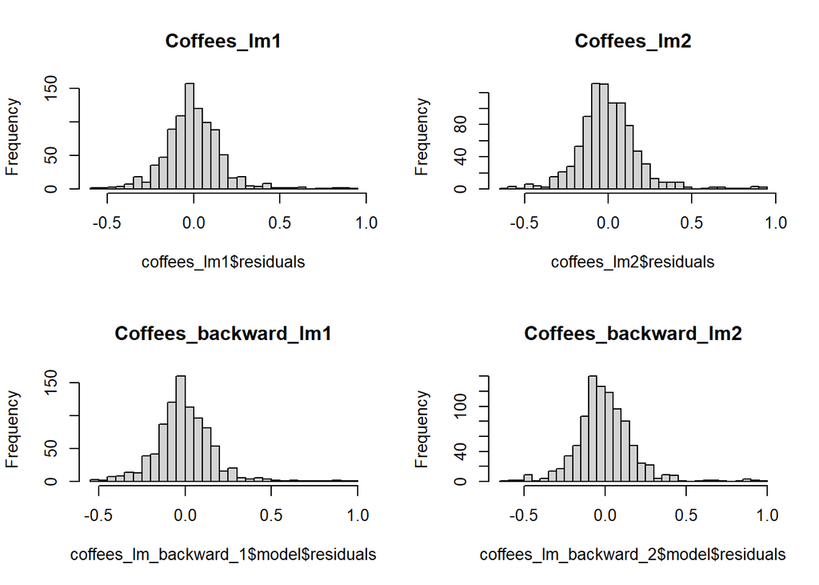

```r
par(mfrow=c(2,2))
hist(coffees_lm1$residuals, breaks = 30, main = "Coffees_lm1")
hist(coffees_lm2$residuals, breaks = 30, main = "Coffees_lm2")
hist(coffees_lm_backward_1$model$residuals, breaks = 30, main = "Coffees_backward_lm1")
hist(coffees_lm_backward_2$model$residuals, breaks = 30, main = "Coffees_backward_lm2")
```

Model stats:

```r
lm_forcasts <-
  data.frame(
    regr_metrics_lm1 = predict(coffees_lm1),
    regr_metrics_lm2 = predict(coffees_lm2),
    regr_metrics_backward1 = predict(coffees_lm_backward_1$model),
    regr_metrics_backward2 = predict(coffees_lm_backward_2$model)
    )

sapply(lm_forcasts,
       function(x) regressionMetrics(real = coffees_train$Cupper.Points,
                                        predicted = x))
```

```
##       regr_metrics_lm1 regr_metrics_lm2 regr_metrics_backward1
## MSE   0.0302545        0.03261977       0.03064914
## RMSE  0.1739382        0.1806095        0.175069
## MAE   0.1225276        0.1281175        0.1232967
## MedAE 0.09199434       0.09354114       0.09097715
## MSLE  0.0004112481     0.000443927      0.0004163918
## R2    0.804655         0.789383         0.8021069
##       regr_metrics_backward2
## MSE   0.03313119
## RMSE  0.1820198
## MAE   0.128165
## MedAE 0.09358055
## MSLE  0.0004510991
## R2    0.786081
```

Now I create controls for cross validation:

```r
ctrl_cv2 <- trainControl(method = "cv",
                          number = 2)

ctrl_cv10 <- trainControl(method = "cv",
                          number = 10)
```

## 3.2 GLM model

I estimate the General Linear Model with all variables and without Region and Country variables:

```r
set.seed(987654321)

coffees_glm_1_cv2 <-
  train(Cupper.Points ~ .,
        data = coffees_train %>%
          dplyr::select(all_of(coffees_variables_all)),
        method = "glm",
        metric = "RMSE",
        trControl = ctrl_cv2)

coffees_glm_1_cv10 <-
  train(Cupper.Points ~ .,
        data = coffees_train %>%
          dplyr::select(all_of(coffees_variables_all)),
        method = "glm",
        metric = "RMSE",
        trControl = ctrl_cv10)

coffees_glm_2_cv2 <-
  train(Cupper.Points ~ .,
        data = coffees_train %>%
          dplyr::select(all_of(coffees_variables_all2)),
        method = "glm",
        metric = "RMSE",
        trControl = ctrl_cv2)

coffees_glm_2_cv10 <-
  train(Cupper.Points ~ .,
        data = coffees_train %>%
          dplyr::select(all_of(coffees_variables_all2)),
        method = "glm",
        metric = "RMSE",
        trControl = ctrl_cv10)
```

## 3.3 KNN model

```r
set.seed(987654321)

coffees_knn_1_cv2 <-
  train(Cupper.Points ~ .,
        data = coffees_train %>%
          dplyr::select(all_of(coffees_variables_all)),
        method = "knn",
        metric = "RMSE",
        trControl = ctrl_cv2)

coffees_knn_1_cv10 <-
  train(Cupper.Points ~ .,
        data = coffees_train %>%
          dplyr::select(all_of(coffees_variables_all)),
        method = "knn",
        metric = "RMSE",
        trControl = ctrl_cv10)

coffees_knn_2_cv2 <-
  train(Cupper.Points ~ .,
        data = coffees_train %>%
          dplyr::select(all_of(coffees_variables_all2)),
        method = "knn",
        metric = "RMSE",
        trControl = ctrl_cv2)

coffees_knn_2_cv10 <-
  train(Cupper.Points ~ .,
        data = coffees_train %>%
          dplyr::select(all_of(coffees_variables_all2)),
        method = "knn",
        metric = "RMSE",
        trControl = ctrl_cv10)
```

## 3.4 LASSO Model

```r
parameters_lasso <- expand.grid(alpha = 1,
                                lambda = seq(10, 1e5, 100))


set.seed(123456789)

coffees_lasso <-  train(Cupper.Points ~ .,
                       data = coffees_train %>%
                         dplyr::select(all_of(coffees_variables_all)),
                       method = "glmnet",
                       tuneGrid = parameters_lasso,
                       trControl = ctrl_cv10)
```

Models comparison:

```r
models_forcasts <-
  data.frame(
    GLM1 = predict(coffees_glm_1_cv10,coffees_test),
    GLM2 = predict(coffees_glm_2_cv10,coffees_test),
    KNN1 = predict(coffees_knn_1_cv10,coffees_test),
    KNN2 = predict(coffees_knn_2_cv10,coffees_test),
    LASSO = predict(coffees_lasso,coffees_test)
    )

sapply(models_forcasts,
       function(x) regressionMetrics(real = coffees_test$Cupper.Points,
                                        predicted = x))
```

```
##       GLM1         GLM2         KNN1       KNN2        LASSO
## MSE   0.07732528   0.07501572   0.1397743  0.1385196   0.1778125
## RMSE  0.2780742    0.27389      0.373864   0.3721822   0.4216782
## MAE   0.1432694    0.1442826    0.2659763  0.2628268   0.2997219
## MedAE 0.1014087    0.1025869    0.2071429  0.2         0.2418943
## MSLE  0.0009594597 0.0009285225 0.00186801 0.001846849 0.00240981
## R2    0.5649241    0.577919     0.2135505  0.22061     -0.0004741536
```

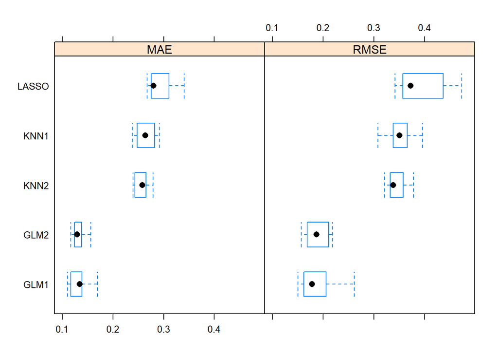

```r
resample_results <- resamples(list(GLM1=coffees_glm_1_cv10,
                                   GLM2=coffees_glm_2_cv10,
                                   KNN1=coffees_knn_1_cv10,
                                   KNN2=coffees_knn_2_cv10,
                                   LASSO=coffees_lasso
                                   ))

bwplot(resample_results , metric = c("RMSE","MAE"))
```

# 4 Summary

It looks, that the best models are linear models. They have lower values of MAE, RMSE and MSE.